# Phase_3_Model_Selection_and_Evaluation

**Jesse Gempel**

**CMP SCI 4300-001**

**Professor Badri Adhikari**

**11/20/2024**

The **diabetes_binary_5050split_health_indicators_BRFSS2015.csv** dataset is suited for a binary classification problem to determine whether a person is:

1. Diabetic or prediabetic (classified as **1**)
2. Non-diabetic (classified as **0**)

This dataset is derived from the "Diabetes Health Indicators Dataset" page on the the Kaggle website. To view the dataset, please visit https://www.kaggle.com/datasets/alexteboul/diabetes-health-indicators-dataset.

**Import all necessary libraries before starting**

```python
import pandas as pd
import numpy as np
import matplotlib.pyplot as plt
import seaborn as sns
from tensorflow.keras.models import Sequential
from tensorflow.keras.layers import Dense
from keras.callbacks import EarlyStopping, ModelCheckpoint
from sklearn.metrics import accuracy_score, precision_score, recall_score, f1_score, roc_auc_score
import random
```

# Phase 1: Data Analysis and Preparation

## 1.) Load dataset

```python
from google.colab import files
x = files.upload()
```

Upload widget is only available when the cell has been executed in the current browser session. Please rerun this cell to enable.

```
Saving diabetes_binary_5050split_health_indicators_BRFSS2015.csv to diabetes_binary_5050split_health_indicators_BRFSS2015 (1).csv
```

```python
dataset = pd.read_csv('diabetes_binary_5050split_health_indicators_BRFSS2015.csv', delimiter=",")
```

## 2.) Examine the dataset shape, rows, and columns

```python
print(dataset.shape)
```

```
(70692, 22)
```

The **diabetes_binary_5050split_health_indicators_BRFSS2015.csv** dataset contains **70,692** instances (rows) and **22** features (columns)---21 of which are considered predictors. These features are:

|  | Attribute | Description |
| --- | --- | --- |
| 1 | **Diabetes_binary** | Does patient have diabetes? (**TARGET VARIABLE)** |
| 2 | HighBP | Is patient's **blood pressure** high? |

[output not shown]

These descriptions were summarized from Kaggle. The link to access fuller descriptions is https://www.kaggle.com/code/alexteboul/diabetes-health-indicators-dataset-notebook.

```python
dataset.head()
```

|  | Diabetes_binary | HighBP | HighChol | CholCheck | BMI | Smoker | Stroke | HeartDiseaseorAttack | PhysActivity | Fruits | ... | AnyHealthcare | NoDocbcCost | GenHlth | MentHlth | PhysHlth | DiffWalk | Sex | Age | Education | Income |
| --- | --- | --- | --- | --- | --- | --- | --- | --- | --- | --- | --- | --- | --- | --- | --- | --- | --- | --- | --- | --- | --- |
| 0 | 0.0 | 1.0 | 0.0 | 1.0 | 26.0 | 0.0 | 0.0 | 0.0 | 1.0 | 0.0 | ... | 1.0 | 0.0 | 3.0 | 5.0 | 30.0 | 0.0 | 1.0 | 4.0 | 6.0 | 8.0 |
| 1 | 0.0 | 1.0 | 1.0 | 1.0 | 26.0 | 1.0 | 1.0 | 0.0 | 0.0 | 1.0 | ... | 1.0 | 0.0 | 3.0 | 0.0 | 0.0 | 0.0 | 1.0 | 12.0 | 6.0 | 8.0 |
| 2 | 0.0 | 0.0 | 0.0 | 1.0 | 26.0 | 0.0 | 0.0 | 0.0 | 1.0 | 1.0 | ... | 1.0 | 0.0 | 1.0 | 0.0 | 10.0 | 0.0 | 1.0 | 13.0 | 6.0 | 8.0 |
| 3 | 0.0 | 1.0 | 1.0 | 1.0 | 28.0 | 1.0 | 0.0 | 0.0 | 1.0 | 1.0 | ... | 1.0 | 0.0 | 3.0 | 0.0 | 3.0 | 0.0 | 1.0 | 11.0 | 6.0 | 8.0 |
| 4 | 0.0 | 0.0 | 0.0 | 1.0 | 29.0 | 1.0 | 0.0 | 0.0 | 1.0 | 1.0 | ... | 1.0 | 0.0 | 2.0 | 0.0 | 0.0 | 0.0 | 0.0 | 8.0 | 5.0 | 8.0 |

5 rows × 22 columns

```python
dataset.tail()
```

|  | Diabetes_binary | HighBP | HighChol | CholCheck | BMI | Smoker | Stroke | HeartDiseaseorAttack | PhysActivity | Fruits | ... | AnyHealthcare | NoDocbcCost | GenHlth | MentHlth | PhysHlth | DiffWalk | Sex | Age | Education | Income |
| --- | --- | --- | --- | --- | --- | --- | --- | --- | --- | --- | --- | --- | --- | --- | --- | --- | --- | --- | --- | --- | --- |
| 70687 | 1.0 | 0.0 | 1.0 | 1.0 | 37.0 | 0.0 | 0.0 | 0.0 | 0.0 | 0.0 | ... | 1.0 | 0.0 | 4.0 | 0.0 | 0.0 | 0.0 | 0.0 | 6.0 | 4.0 | 1.0 |
| 70688 | 1.0 | 0.0 | 1.0 | 1.0 | 29.0 | 1.0 | 0.0 | 1.0 | 0.0 | 1.0 | ... | 1.0 | 0.0 | 2.0 | 0.0 | 0.0 | 1.0 | 1.0 | 10.0 | 3.0 | 6.0 |
| 70689 | 1.0 | 1.0 | 1.0 | 1.0 | 25.0 | 0.0 | 0.0 | 1.0 | 0.0 | 1.0 | ... | 1.0 | 0.0 | 5.0 | 15.0 | 0.0 | 1.0 | 0.0 | 13.0 | 6.0 | 4.0 |
| 70690 | 1.0 | 1.0 | 1.0 | 1.0 | 18.0 | 0.0 | 0.0 | 0.0 | 0.0 | 0.0 | ... | 1.0 | 0.0 | 4.0 | 0.0 | 0.0 | 1.0 | 0.0 | 11.0 | 2.0 | 4.0 |
| 70691 | 1.0 | 1.0 | 1.0 | 1.0 | 25.0 | 0.0 | 0.0 | 1.0 | 1.0 | 1.0 | ... | 1.0 | 0.0 | 2.0 | 0.0 | 0.0 | 0.0 | 0.0 | 9.0 | 6.0 | 2.0 |

5 rows × 22 columns

```python
# .iloc is used to ensure that ALL attribute's values can be seen, unlike the two tables above where they are cut off.

row_number = random.randint(0, len(dataset))
print(f"Attribute information for Row {row_number} out of {len(dataset)} \n\n{dataset.iloc[row_number]}")
```

```
Attribute information for Row 13776 out of 70692

Diabetes_binary          0.0
HighBP                   0.0
HighChol                 0.0
CholCheck                1.0
BMI                     24.0
Smoker                   0.0
Stroke                   0.0
HeartDiseaseorAttack     0.0
PhysActivity             1.0
Fruits                   1.0
Veggies                  1.0
HvyAlcoholConsump        0.0
AnyHealthcare            1.0
NoDocbcCost              0.0
GenHlth                  1.0
MentHlth                 0.0
PhysHlth                 0.0
DiffWalk                 0.0
Sex                      0.0
Age                      7.0
Education                6.0
Income                   7.0
Name: 13776, dtype: float64
```

## 3.) Find any missing data

```python
dataset.isnull().sum()
```

|  | 0 |
| --- | --- |
| Diabetes_binary | 0 |
| HighBP | 0 |
| HighChol | 0 |
| CholCheck | 0 |
| BMI | 0 |
| Smoker | 0 |
| Stroke | 0 |
| HeartDiseaseorAttack | 0 |
| PhysActivity | 0 |
| Fruits | 0 |
| Veggies | 0 |
| HvyAlcoholConsump | 0 |
| AnyHealthcare | 0 |
| NoDocbcCost | 0 |
| GenHlth | 0 |
| MentHlth | 0 |
| PhysHlth | 0 |
| DiffWalk | 0 |
| Sex | 0 |
| Age | 0 |
| Education | 0 |
| Income | 0 |

**dtype:** int64

Because every value in the table above contains a 0, it is apparent that no missing data exists in the dataset.

## 4.) Clean up attribute titles

```python
dataset.columns = ('Diabetes (binary target)',
                   'High Blood Pressure (y/n)',
                   'High Cholesterol (y/n)',
                   'Cholesterol Checked (y/n)',
                   'BMI',
                   'Smoke (y/n)',
                   'Stroke (y/n)',
                   'Heart Attack (y/n)',
                   'Exercise (y/n)',
                   'Fruits (y/n)',
                   'Veggies (y/n)',
                   'Heavy Alcohol Consumption (y/n)',
                   'Health Coverage (y/n)',
                   'Cost Prevents Doctor Visit (y/n)',
                   'General Health (1-5)',
                   'Days Poor Mental Health',
                   'Days Poor Physical Health',
                   'Stairs Difficulty (y/n)',
                   'Sex (M/F)',
                   'Age',
                   'Education',
                   'Income')

# Converts column names to list to make specifying columns for describe() method easier.
column_list = dataset.columns.tolist()
```

## 5.) Visualize distribution of the two classes (output labels)

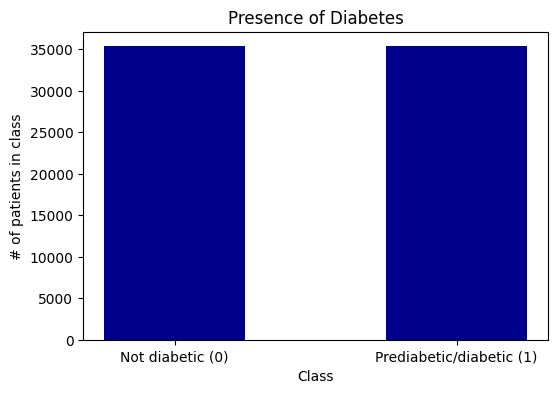

```python
class_distribution = dataset["Diabetes (binary target)"].value_counts().to_dict()
classes = list(class_distribution.keys())
number_of_patients_in_class = list(class_distribution.values())

fig = plt.figure(figsize = (6, 4))

plt.bar(classes, number_of_patients_in_class, color="darkblue", width=0.5)

plt.xlabel("Class")
plt.xticks([0, 1], ["Not diabetic (0)", "Prediabetic/diabetic (1)"])
plt.ylabel("# of patients in class")
plt.title("Presence of Diabetes")

plt.show()
```

```python
diabetic_count = number_of_patients_in_class[1]
non_diabetic_count = number_of_patients_in_class[0]

diabetic_percentage = (diabetic_count / (diabetic_count + non_diabetic_count)) * 100
non_diabetic_percentage = (non_diabetic_count / (diabetic_count + non_diabetic_count)) * 100

print("Class:\t\tDescription:\t\t\t\t\tPatient count:\t\tPercentage:")
print(f"{classes[0]}\t\tNumber of non-diabetic patients\t\t\t{non_diabetic_count}\t\t\t{non_diabetic_percentage}%")
print(f"{classes[1]}\t\tNumber of pre-diabetic/diabetic patients\t{diabetic_count}\t\t\t{diabetic_percentage}%")
```

```
Class:		Description:					Patient count:		Percentage:
0.0		Number of non-diabetic patients			35346			50.0%
1.0		Number of pre-diabetic/diabetic patients	35346			50.0%
```

Upon observing the distribution of the two classes above, it turns out that the data is *equally distributed*. Both classes appear to have exactly **35,346** rows, plus the distribution percentages are exactly **50.0%**. Therefore, it is safe to say that the data is not heavily imbalanced (or even remotely imbalanced at all). We can continue utilizing the dataset to solve this binary classification problem.

## 6.) Visualize distribution of all predictors with histogram (input labels)

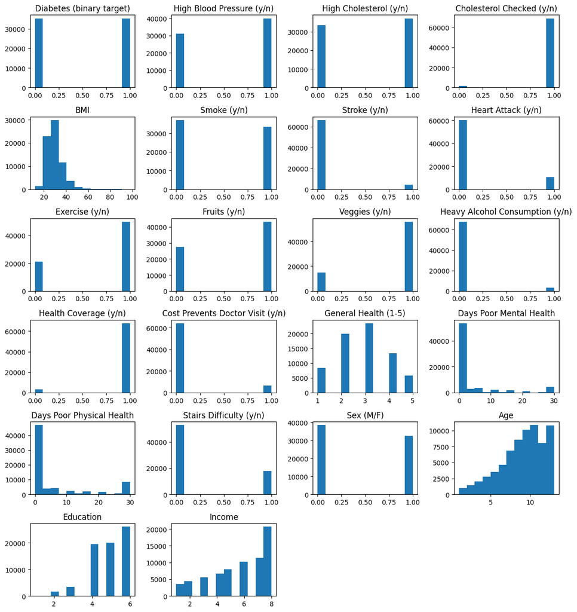

```python
%matplotlib inline

histogram = dataset.hist(figsize=(12, 13), layout=(6, 4), bins=12, grid=False)

plt.tight_layout()
plt.show()
```

## 7.) Illustrate range of values for predictors

#### **7.1: Range of values for predictors 1 through 7**

```python
dataset[column_list[1:8]].describe()
```

|  | High Blood Pressure (y/n) | High Cholesterol (y/n) | Cholesterol Checked (y/n) | BMI | Smoke (y/n) | Stroke (y/n) | Heart Attack (y/n) |
| --- | --- | --- | --- | --- | --- | --- | --- |
| count | 70692.000000 | 70692.000000 | 70692.000000 | 70692.000000 | 70692.000000 | 70692.000000 | 70692.000000 |
| mean | 0.563458 | 0.525703 | 0.975259 | 29.856985 | 0.475273 | 0.062171 | 0.147810 |
| std | 0.495960 | 0.499342 | 0.155336 | 7.113954 | 0.499392 | 0.241468 | 0.354914 |
| min | 0.000000 | 0.000000 | 0.000000 | 12.000000 | 0.000000 | 0.000000 | 0.000000 |
| 25% | 0.000000 | 0.000000 | 1.000000 | 25.000000 | 0.000000 | 0.000000 | 0.000000 |
| 50% | 1.000000 | 1.000000 | 1.000000 | 29.000000 | 0.000000 | 0.000000 | 0.000000 |
| 75% | 1.000000 | 1.000000 | 1.000000 | 33.000000 | 1.000000 | 0.000000 | 0.000000 |
| max | 1.000000 | 1.000000 | 1.000000 | 98.000000 | 1.000000 | 1.000000 | 1.000000 |

For the first seven columns of the dataset, every predictor above (except BMI) appears to have a range between 0 and 1. This scenerio occurs because those attributes only hold binary values (0 or 1). When the data was gathered, each patient was asked yes/no questions about their blood pressure, cholesterol, checking of cholesterol, smoking habits, stroke history, and heart attack history.

#### **7.2: Range of values for predictors 8 through 13**

```python
dataset[column_list[8:14]].describe()
```

|  | Exercise (y/n) | Fruits (y/n) | Veggies (y/n) | Heavy Alcohol Consumption (y/n) | Health Coverage (y/n) | Cost Prevents Doctor Visit (y/n) |
| --- | --- | --- | --- | --- | --- | --- |
| count | 70692.000000 | 70692.000000 | 70692.000000 | 70692.000000 | 70692.000000 | 70692.000000 |
| mean | 0.703036 | 0.611795 | 0.788774 | 0.042721 | 0.954960 | 0.093914 |
| std | 0.456924 | 0.487345 | 0.408181 | 0.202228 | 0.207394 | 0.291712 |
| min | 0.000000 | 0.000000 | 0.000000 | 0.000000 | 0.000000 | 0.000000 |
| 25% | 0.000000 | 0.000000 | 1.000000 | 0.000000 | 1.000000 | 0.000000 |
| 50% | 1.000000 | 1.000000 | 1.000000 | 0.000000 | 1.000000 | 0.000000 |
| 75% | 1.000000 | 1.000000 | 1.000000 | 0.000000 | 1.000000 | 0.000000 |
| max | 1.000000 | 1.000000 | 1.000000 | 1.000000 | 1.000000 | 1.000000 |

In the table above, patients were asked yes/no questions about their exercise habits, fruit/vegetable intake, alcohol intake, health coverage, and their ability to attend doctor's visits due to cost. For this reason, all the quartile values only contain integer values 0 or 1.

#### **7.3: Range of values for predictors 14 through 22**

```python
dataset[column_list[14:22]].describe()
```

|  | General Health (1-5) | Days Poor Mental Health | Days Poor Physical Health | Stairs Difficulty (y/n) | Sex (M/F) | Age | Education | Income |
| --- | --- | --- | --- | --- | --- | --- | --- | --- |
| count | 70692.000000 | 70692.000000 | 70692.000000 | 70692.000000 | 70692.000000 | 70692.000000 | 70692.000000 | 70692.000000 |
| mean | 2.837082 | 3.752037 | 5.810417 | 0.252730 | 0.456997 | 8.584055 | 4.920953 | 5.698311 |
| std | 1.113565 | 8.155627 | 10.062261 | 0.434581 | 0.498151 | 2.852153 | 1.029081 | 2.175196 |
| min | 1.000000 | 0.000000 | 0.000000 | 0.000000 | 0.000000 | 1.000000 | 1.000000 | 1.000000 |
| 25% | 2.000000 | 0.000000 | 0.000000 | 0.000000 | 0.000000 | 7.000000 | 4.000000 | 4.000000 |
| 50% | 3.000000 | 0.000000 | 0.000000 | 0.000000 | 0.000000 | 9.000000 | 5.000000 | 6.000000 |
| 75% | 4.000000 | 2.000000 | 6.000000 | 1.000000 | 1.000000 | 11.000000 | 6.000000 | 8.000000 |
| max | 5.000000 | 30.000000 | 30.000000 | 1.000000 | 1.000000 | 13.000000 | 6.000000 | 8.000000 |

Quartile values for **Stairs Difficulty** and **Sex (M/F)** are exclusively 0 or 1. This scenario occurs due to the nature of their data holding binary values. The data for the Stairs Difficulty feature was gathered through a yes/no question asked from the doctor to the patient. The Sex (M/F) assigns a 0 for female and a 1 for male.

The **General Health (1-5)** predictor holds data that serves as a rating from 1 to 5. Only 5 possible values exist for that predictor, so the quartiles appear to behave almost uniformly as the values increase.

The **Education** predictor categorizes values between 1 and 6. This method of categorization can be found on https://www.icpsr.umich.edu/web/NAHDAP/studies/34085/datasets/0001/variables/EDUCA?archive=NAHDAP. When comparing the lower quartile to the maximum value, the values range between 4 and 6. This observation dictates that around 75% of people in the study obtained at least a high school degree or GED.

This dataset also uses numbers to illustrate categories for the **Income** predictor. Values 1 through 8 represent an income bracket in which a patient belongs. This breakdown is demonstrated at https://www.icpsr.umich.edu/web/RCMD/studies/34085/datasets/0001/variables/INCOME2?archive=RCMD. The mean and median appear to be around 6, meaning that the average person in the study appears to make between $35,000 and $50,000/yr. It can also be said that at least 25% of patients make over $75,000/yr since the upper quartile (75%) equals the maximum value.

## 8.) Illustrate range of values for target variable Diabetes (binary target)

```python
dataset[column_list[0]].describe()
```

|  | Diabetes (binary target) |
| --- | --- |
| count | 70692.000000 |
| mean | 0.500000 |
| std | 0.500004 |
| min | 0.000000 |
| 25% | 0.000000 |
| 50% | 0.500000 |
| 75% | 1.000000 |
| max | 1.000000 |

**dtype:** float64

The target variable **Diabetes (binary target)** contains an *exactly* equal breakdown of 0's and 1's---0 for if a patient is ***not* diabetic**, and 1 if a patient is either **diabetic or prediabetic**. As a result, the minimum value equals the lower quartile (25%), the maximum value equals the upper quartile (75%), and the median equals the mean.

## 9.) Normalize the data

```python
mean = dataset.mean(axis=0)
stddev = dataset.std(axis=0)

norm_dataset = (dataset - mean) / stddev
```

## 10.) Visualize *normalized* distributions with histogram

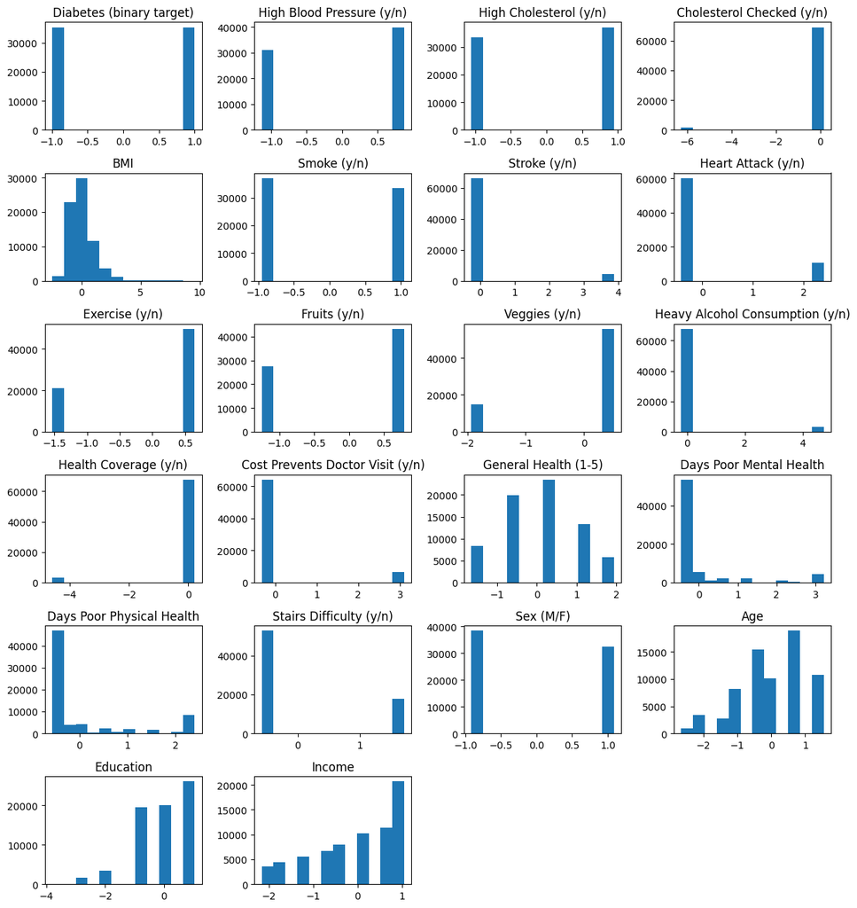

```python
%matplotlib inline

histogram = norm_dataset.hist(figsize=(12, 13), layout=(6, 4), bins=12, grid=False)

plt.tight_layout()
plt.show()
```

# Phase 2 (removed for condensing purposes)

# Phase 3: Selecting and Evaluating Models

## 1.) Select features and target variables

```python
X = norm_dataset.iloc[:, 1:]
Y = dataset.iloc[:, 0]                      # Use the original output values BEFORE normalization happened.
                                            # That way, the model can continue working with binary output values.
                                            # Output columns are somehow in the FIRST column with this dataset.

data_final = pd.concat([Y, X], axis=1)      # Combine normalized features and target.
```

```python
data_final.head()
```

|  | Diabetes (binary target) | High Blood Pressure (y/n) | High Cholesterol (y/n) | Cholesterol Checked (y/n) | BMI | Smoke (y/n) | Stroke (y/n) | Heart Attack (y/n) | Exercise (y/n) | Fruits (y/n) | ... | Health Coverage (y/n) | Cost Prevents Doctor Visit (y/n) | General Health (1-5) | Days Poor Mental Health | Days Poor Physical Health | Stairs Difficulty (y/n) | Sex (M/F) | Age | Education | Income |
| --- | --- | --- | --- | --- | --- | --- | --- | --- | --- | --- | --- | --- | --- | --- | --- | --- | --- | --- | --- | --- | --- |
| 0 | 0.0 | 0.880195 | -1.052791 | 0.159275 | -0.542172 | -0.951704 | -0.257472 | -0.416467 | 0.649921 | -1.255363 | ... | 0.217173 | -0.321943 | 0.146303 | 0.153019 | 2.403991 | -0.58155 | 1.090038 | -1.607226 | 1.048554 | 1.058152 |
| 1 | 0.0 | 0.880195 | 0.949843 | 0.159275 | -0.542172 | 1.050732 | 3.883868 | -0.416467 | -1.538628 | 0.796571 | ... | 0.217173 | -0.321943 | 0.146303 | -0.460055 | -0.577446 | -0.58155 | 1.090038 | 1.197672 | 1.048554 | 1.058152 |
| 2 | 0.0 | -1.136096 | -1.052791 | 0.159275 | -0.542172 | -0.951704 | -0.257472 | -0.416467 | 0.649921 | 0.796571 | ... | 0.217173 | -0.321943 | -1.649731 | -0.460055 | 0.416366 | -0.58155 | 1.090038 | 1.548285 | 1.048554 | 1.058152 |
| 3 | 0.0 | 0.880195 | 0.949843 | 0.159275 | -0.261034 | 1.050732 | -0.257472 | -0.416467 | 0.649921 | 0.796571 | ... | 0.217173 | -0.321943 | 0.146303 | -0.460055 | -0.279303 | -0.58155 | 1.090038 | 0.847060 | 1.048554 | 1.058152 |
| 4 | 0.0 | -1.136096 | -1.052791 | 0.159275 | -0.120465 | 1.050732 | -0.257472 | -0.416467 | 0.649921 | 0.796571 | ... | 0.217173 | -0.321943 | -0.751714 | -0.460055 | -0.577446 | -0.58155 | -0.917386 | -0.204777 | 0.076813 | 1.058152 |

5 rows × 22 columns

## 2.) Shuffle the rows/samples

```python
data_final = data_final.sample(frac=1).reset_index(drop=True)
```

## 3.) Divide data into training and validation sets

For the splitting of the training and validation sets, we will divide the **Diabetes Health Indicators Dataset** from Kaggle in this manner:

```python
data_30_percent = int(0.3 * len(data_final))
```

```python
X_training = data_final.iloc[:data_30_percent, 1:]
Y_training = data_final.iloc[:data_30_percent, 0]

X_validation = data_final.iloc[data_30_percent:, 1:]
Y_validation = data_final.iloc[data_30_percent:, 0]
```

## 4.) Review the shapes of each set

```python
print("X_training shape:\t", X_training.shape)
print("Y_training shape:\t", Y_training.shape)
print("X_validation shape:\t", X_validation.shape)
print("Y_validation shape:\t", Y_validation.shape)

print("\nX shape:\t\t", X.shape)
print("Y shape:\t\t", Y.shape)
```

```
X_training shape:	 (21207, 21)
Y_training shape:	 (21207,)
X_validation shape:	 (49485, 21)
Y_validation shape:	 (49485,)

X shape:		 (70692, 21)
Y shape:		 (70692,)
```

## 5.) Determine a random baseline classifier

The **random baseline classifier** is an entity that results in a model performance comparison metric. The classifier will be based on the size of each of the data's classes. To elaborate, the accuracy of the random baseline classifier will *equal* the percentage of samples inside the largest class.

**Review class distribution**

As a recap, a binary value of **0** indicates that a patient does *not* have diabetes, and a value of **1** resembles a patient *with* diabetes (or a prediabetic condition).

```python
print(class_distribution)
```

```
{0.0: 35346, 1.0: 35346}
```

**Determine the larget class in the dataset**

```python
largest_class_size = max(zip(class_distribution.keys(), class_distribution.values()))[1]
print("Largest class size:", largest_class_size)
```

```
Largest class size: 35346
```

In this particular scenario, the two class sizes are exactly equal. No class can be considered the largest, so the random baseline classifer's accuracy will be **50%**. That means that any model created at this point needs to perform better than a 50% accuracy.

```python
data_size = dataset.shape[0]

random_baseline_accuracy = (largest_class_size / data_size) * 100
print(f"Random baseline accuracy: {random_baseline_accuracy}%")
```

```
Random baseline accuracy: 50.0%
```

## 6.) Train multiple models

```python
# There are a total of 7 models in Phase 3, plus the random baseline classifier.
num_models = 8

# These NumPy arrays will store the accuracies for tabular visualization.
training_accuracies = np.zeros((num_models, 1), dtype=float)
validation_accuracies = np.zeros((num_models, 1), dtype=float)

# These are the accuracies for the Random Baseline Classifier. They will be placed in a table.
training_accuracies[0] = 50.0
validation_accuracies[0] = 50.0

# These 10 NumPy arrays will store loss, recall, F1-score, ROC-AUC, parameter, and epoch information for table usage.
training_losses = np.zeros((num_models, 1), dtype=float)
validation_losses = np.zeros((num_models, 1), dtype=float)

training_recalls = np.zeros((num_models, 1), dtype=float)
validation_recalls = np.zeros((num_models, 1), dtype=float)

training_f1_scores = np.zeros((num_models, 1), dtype=float)
validation_f1_scores = np.zeros((num_models, 1), dtype=float)

training_roc_auc_scores = np.zeros((num_models, 1), dtype=float)
validation_roc_auc_scores = np.zeros((num_models, 1), dtype=float)

parameter_counts = np.zeros((num_models, 1), dtype=int)
epoch_counts = np.zeros((num_models, 1), dtype=int)
```

### 6.1: Simple logistic regression model

#### **Create the model**

```python
model_number = 1

model = Sequential()
model.add(Dense(1, activation='sigmoid', input_shape=(X.shape[1],)))
```

```python
model.summary()

# Used to create tabular data.
parameter_counts[model_number] = model.count_params()
```

```
Model: "sequential_1"
```

```
┏━━━━━━━━━━━━━━━━━━━━━━━━━━━━━━━━━━━━━━┳━━━━━━━━━━━━━━━━━━━━━━━━━━━━━┳━━━━━━━━━━━━━━━━━┓
┃ Layer (type)                         ┃ Output Shape                ┃         Param # ┃
┡━━━━━━━━━━━━━━━━━━━━━━━━━━━━━━━━━━━━━━╇━━━━━━━━━━━━━━━━━━━━━━━━━━━━━╇━━━━━━━━━━━━━━━━━┩
│ dense_1 (Dense)                      │ (None, 1)                   │              22 │
└──────────────────────────────────────┴─────────────────────────────┴─────────────────┘
```

```
 Total params: 22 (88.00 B)
```

```
 Trainable params: 22 (88.00 B)
```

```
 Non-trainable params: 0 (0.00 B)
```

#### **Compile and run the model**

```python
model.compile(loss='binary_crossentropy', optimizer = 'rmsprop', metrics=['accuracy','recall'])
callback_a = ModelCheckpoint(filepath = 'my_best_model.weights.h5', monitor='val_loss', save_best_only = True, save_weights_only = True, verbose = 1)
callback_b = EarlyStopping(monitor='val_loss', mode='min', patience=40, verbose=1)


history = model.fit(X_training, Y_training, validation_data=(X_validation, Y_validation), epochs=200,
                           batch_size=16, callbacks = [callback_a, callback_b])
```

```
1324/1326 ━━━━━━━━━━━━━━━━━━━━ 0s 2ms/step - accuracy: 0.6027 - loss: 0.7277 - recall: 0.5752
Epoch 1: val_loss improved from inf to 0.53157, saving model to my_best_model.weights.h5
1326/1326 ━━━━━━━━━━━━━━━━━━━━ 11s 8ms/step - accuracy: 0.6028 - loss: 0.7275 - recall: 0.5754 - val_accuracy: 0.7370 - val_loss: 0.5316 - val_recall: 0.7555
1305/1326 ━━━━━━━━━━━━━━━━━━━━ 0s 2ms/step - accuracy: 0.7414 - loss: 0.5253 - recall: 0.7656
Epoch 2: val_loss improved from 0.53157 to 0.51319, saving model to my_best_model.weights.h5
1326/1326 ━━━━━━━━━━━━━━━━━━━━ 18s 6ms/step - accuracy: 0.7414 - loss: 0.5253 - recall: 0.7656 - val_accuracy: 0.7489 - val_loss: 0.5132 - val_recall: 0.7717
1295/1326 ━━━━━━━━━━━━━━━━━━━━ 0s 1ms/step - accuracy: 0.7440 - loss: 0.5168 - recall: 0.7635
Epoch 3: val_loss improved from 0.51319 to 0.51115, saving model to my_best_model.weights.h5
1326/1326 ━━━━━━━━━━━━━━━━━━━━ 8s 4ms/step - accuracy: 0.7440 - loss: 0.5169 - recall: 0.7635 - val_accuracy: 0.7492 - val_loss: 0.5111 - val_recall: 0.7775
1312/1326 ━━━━━━━━━━━━━━━━━━━━ 0s 2ms/step - accuracy: 0.7445 - loss: 0.5178 - recall: 0.7743
Epoch 4: val_loss improved from 0.51115 to 0.51083, saving model to my_best_model.weights.h5
1326/1326 ━━━━━━━━━━━━━━━━━━━━ 8s 6ms/step - accuracy: 0.7445 - loss: 0.5178 - recall: 0.7742 - val_accuracy: 0.7485 - val_loss: 0.5108 - val_recall: 0.7629
1300/1326 ━━━━━━━━━━━━━━━━━━━━ 0s 1ms/step - accuracy: 0.7497 - loss: 0.5143 - recall: 0.7679
Epoch 5: val_loss improved from 0.51083 to 0.51076, saving model to my_best_model.weights.h5
1326/1326 ━━━━━━━━━━━━━━━━━━━━ 8s 4ms/step - accuracy: 0.7496 - loss: 0.5144 - recall: 0.7678 - val_accuracy: 0.7498 - val_loss: 0.5108 - val_recall: 0.7773
1318/1326 ━━━━━━━━━━━━━━━━━━━━ 0s 2ms/step - accuracy: 0.7416 - loss: 0.5196 - recall: 0.7614
Epoch 6: val_loss improved from 0.51076 to 0.51067, saving model to my_best_model.weights.h5
1326/1326 ━━━━━━━━━━━━━━━━━━━━ 8s 6ms/step - accuracy: 0.7417 - loss: 0.5196 - recall: 0.7614 - val_accuracy: 0.7492 - val_loss: 0.5107 - val_recall: 0.7716
1306/1326 ━━━━━━━━━━━━━━━━━━━━ 0s 1ms/step - accuracy: 0.7455 - loss: 0.5179 - recall: 0.7710
Epoch 7: val_loss did not improve from 0.51067
1326/1326 ━━━━━━━━━━━━━━━━━━━━ 7s 4ms/step - accuracy: 0.7454 - loss: 0.5179 - recall: 0.7709 - val_accuracy: 0.7494 - val_loss: 0.5108 - val_recall: 0.7734
1302/1326 ━━━━━━━━━━━━━━━━━━━━ 0s 1ms/step - accuracy: 0.7409 - loss: 0.5217 - recall: 0.7674
Epoch 8: val_loss improved from 0.51067 to 0.51054, saving model to my_best_model.weights.h5
1326/1326 ━━━━━━━━━━━━━━━━━━━━ 10s 4ms/step - accuracy: 0.7409 - loss: 0.5216 - recall: 0.7673 - val_accuracy: 0.7498 - val_loss: 0.5105 - val_recall: 0.7740
1310/1326 ━━━━━━━━━━━━━━━━━━━━ 0s 1ms/step - accuracy: 0.7458 - loss: 0.5154 - recall: 0.7634
Epoch 9: val_loss did not improve from 0.51054
1326/1326 ━━━━━━━━━━━━━━━━━━━━ 7s 5ms/step - accuracy: 0.7457 - loss: 0.5155 - recall: 0.7634 - val_accuracy: 0.7495 - val_loss: 0.5106 - val_recall: 0.7690
1291/1326 ━━━━━━━━━━━━━━━━━━━━ 0s 1ms/step - accuracy: 0.7451 - loss: 0.5144 - recall: 0.7643
Epoch 10: val_loss did not improve from 0.51054
1326/1326 ━━━━━━━━━━━━━━━━━━━━ 5s 4ms/step - accuracy: 0.7450 - loss: 0.5145 - recall: 0.7643 - val_accuracy: 0.7486 - val_loss: 0.5107 - val_recall: 0.7673
1298/1326 ━━━━━━━━━━━━━━━━━━━━ 0s 1ms/step - accuracy: 0.7471 - loss: 0.5117 - recall: 0.7652
Epoch 11: val_loss did not improve from 0.51054
1326/1326 ━━━━━━━━━━━━━━━━━━━━ 7s 5ms/step - accuracy: 0.7470 - loss: 0.5119 - recall: 0.7651 - val_accuracy: 0.7498 - val_loss: 0.5107 - val_recall: 0.7767
1304/1326 ━━━━━━━━━━━━━━━━━━━━ 0s 1ms/step - accuracy: 0.7389 - loss: 0.5278 - recall: 0.7609
Epoch 12: val_loss did not improve from 0.51054
1326/1326 ━━━━━━━━━━━━━━━━━━━━ 9s 4ms/step - accuracy: 0.7389 - loss: 0.5276 - recall: 0.7610 - val_accuracy: 0.7496 - val_loss: 0.5109 - val_recall: 0.7693
1312/1326 ━━━━━━━━━━━━━━━━━━━━ 0s 1ms/step - accuracy: 0.7482 - loss: 0.5145 - recall: 0.7663
Epoch 13: val_loss did not improve from 0.51054
1326/1326 ━━━━━━━━━━━━━━━━━━━━ 10s 4ms/step - accuracy: 0.7481 - loss: 0.5145 - recall: 0.7663 - val_accuracy: 0.7493 - val_loss: 0.5106 - val_recall: 0.7698
1307/1326 ━━━━━━━━━━━━━━━━━━━━ 0s 2ms/step - accuracy: 0.7438 - loss: 0.5186 - recall: 0.7620
```

[output cut: 288 more lines]

```
Epoch 110: val_loss did not improve from 0.51039
1326/1326 ━━━━━━━━━━━━━━━━━━━━ 7s 5ms/step - accuracy: 0.7443 - loss: 0.5145 - recall: 0.7619 - val_accuracy: 0.7494 - val_loss: 0.5106 - val_recall: 0.7766
1308/1326 ━━━━━━━━━━━━━━━━━━━━ 0s 2ms/step - accuracy: 0.7407 - loss: 0.5175 - recall: 0.7653
Epoch 111: val_loss did not improve from 0.51039
1326/1326 ━━━━━━━━━━━━━━━━━━━━ 9s 4ms/step - accuracy: 0.7408 - loss: 0.5175 - recall: 0.7653 - val_accuracy: 0.7489 - val_loss: 0.5108 - val_recall: 0.7677
1326/1326 ━━━━━━━━━━━━━━━━━━━━ 0s 2ms/step - accuracy: 0.7506 - loss: 0.5124 - recall: 0.7698
Epoch 112: val_loss did not improve from 0.51039
1326/1326 ━━━━━━━━━━━━━━━━━━━━ 12s 5ms/step - accuracy: 0.7506 - loss: 0.5124 - recall: 0.7698 - val_accuracy: 0.7495 - val_loss: 0.5107 - val_recall: 0.7733
1312/1326 ━━━━━━━━━━━━━━━━━━━━ 0s 2ms/step - accuracy: 0.7441 - loss: 0.5183 - recall: 0.7698
Epoch 113: val_loss did not improve from 0.51039
1326/1326 ━━━━━━━━━━━━━━━━━━━━ 8s 4ms/step - accuracy: 0.7441 - loss: 0.5183 - recall: 0.7697 - val_accuracy: 0.7488 - val_loss: 0.5106 - val_recall: 0.7697
1324/1326 ━━━━━━━━━━━━━━━━━━━━ 0s 2ms/step - accuracy: 0.7402 - loss: 0.5186 - recall: 0.7564
Epoch 114: val_loss did not improve from 0.51039
1326/1326 ━━━━━━━━━━━━━━━━━━━━ 7s 5ms/step - accuracy: 0.7403 - loss: 0.5186 - recall: 0.7565 - val_accuracy: 0.7499 - val_loss: 0.5108 - val_recall: 0.7731
Epoch 114: early stopping
```

#### **Evaluate the model**

```python
model.load_weights('my_best_model.weights.h5')
```

```python
train_scores = model.evaluate(X_training, Y_training)
val_scores = model.evaluate(X_validation, Y_validation)
```

```
663/663 ━━━━━━━━━━━━━━━━━━━━ 1s 1ms/step - accuracy: 0.7495 - loss: 0.5144 - recall: 0.7729
1547/1547 ━━━━━━━━━━━━━━━━━━━━ 2s 1ms/step - accuracy: 0.7461 - loss: 0.5137 - recall: 0.7678
```

```python
prediction_train = model.predict(X_training)
prediction_val = model.predict(X_validation)
```

```
663/663 ━━━━━━━━━━━━━━━━━━━━ 1s 1ms/step
1547/1547 ━━━━━━━━━━━━━━━━━━━━ 2s 1ms/step
```

```python
# For training and validation accuracy.
training_accuracies[model_number] = (accuracy_score(Y_training, prediction_train.round())) * 100
validation_accuracies[model_number] = (accuracy_score(Y_validation, prediction_val.round())) * 100
train_acc = training_accuracies[model_number]
val_acc = validation_accuracies[model_number]

# For training and validation loss.
training_losses[model_number] = train_scores[0]
validation_losses[model_number] = val_scores[0]
train_loss = training_losses[model_number]
val_loss = validation_losses[model_number]

# For training and validation recall.
training_recalls[model_number] = recall_score(Y_training, prediction_train.round())
validation_recalls[model_number] = recall_score(Y_validation, prediction_val.round())
train_recall = training_recalls[model_number]
val_recall = validation_recalls[model_number]

# For training and validation F1-score.
training_f1_scores[model_number] = f1_score(Y_training, prediction_train.round())
validation_f1_scores[model_number] = f1_score(Y_validation, prediction_val.round())
train_f1_score = training_f1_scores[model_number]
val_f1_score = validation_f1_scores[model_number]

# For training and validation AUC-ROC score.
training_roc_auc_scores[model_number] = roc_auc_score(Y_training, prediction_train.round())
validation_roc_auc_scores[model_number] = roc_auc_score(Y_validation, prediction_val.round())
train_roc_auc = training_roc_auc_scores[model_number]
val_roc_auc = validation_roc_auc_scores[model_number]

# For epoch count.
epoch_counts[model_number] = len(history.history['loss'])
epochs = epoch_counts[model_number]

print("\t\tTraining\tValidation")
print(f"Accuracy: \t{train_acc.item():.2f}% \t\t{val_acc.item():.2f}%")
print(f"Loss: \t\t{train_loss.item():.4f}\t\t{val_loss.item():.4f}")
print(f"Recall: \t{train_recall.item():.4f} \t\t{val_recall.item():.4f}")
print(f"F1-score: \t{train_f1_score.item():.4f} \t\t{val_f1_score.item():.4f}")
print(f"AUC-ROC score: \t{train_roc_auc.item():.4f} \t\t{train_roc_auc.item():.4f}")

print("\nPredictions:", prediction_val[0:10].T.round())
print("Number of epochs ran:\t", epochs.item())
```

```
		Training	Validation
Accuracy: 	74.48% 		74.99%
Loss: 		0.5170		0.5104
Recall: 	0.7674 		0.7733
F1-score: 	0.7510 		0.7554
AUC-ROC score: 	0.7448 		0.7448

Predictions: [[0. 0. 1. 1. 0. 0. 1. 0. 0. 0.]]
Number of epochs ran:	 114
```

#### **Visualize the model's results**

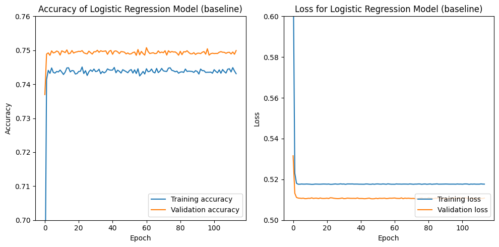

```python
import matplotlib.pyplot as plt

fig, axes = plt.subplots(1, 2, figsize=(10, 5))

axes[0].plot(history.history['accuracy'], label='Training accuracy')
axes[0].plot(history.history['val_accuracy'], label='Validation accuracy')
axes[0].set_title("Accuracy of Logistic Regression Model (baseline)")
axes[0].set_xlabel('Epoch')
axes[0].set_ylabel('Accuracy')
axes[0].set_ylim([0.7, 0.76])
axes[0].legend(loc='lower right')

axes[1].plot(history.history['loss'], label='Training loss')
axes[1].plot(history.history['val_loss'], label='Validation loss')
axes[1].set_title("Loss for Logistic Regression Model (baseline)")
axes[1].set_xlabel('Epoch')
axes[1].set_ylabel('Loss')
axes[1].set_ylim([0.5, 0.6])
axes[1].legend(loc='lower right')

plt.tight_layout()
plt.show()
```

### 6.2: The **(128-64-32-16-1)** architecture neural network

#### **Create the model**

```python
model_number = 2

model = Sequential()

model.add(Dense(128, activation='relu', input_shape=(X.shape[1],)))
model.add(Dense(64, activation='relu'))
model.add(Dense(32, activation='relu'))
model.add(Dense(16, activation='relu'))

model.add(Dense(1, activation='sigmoid'))
```

```python
print((X.shape[1]))
```

```
21
```

```python
model.summary()

# Used to create tabular data.
parameter_counts[model_number] = model.count_params()
```

```
Model: "sequential_2"
```

```
┏━━━━━━━━━━━━━━━━━━━━━━━━━━━━━━━━━━━━━━┳━━━━━━━━━━━━━━━━━━━━━━━━━━━━━┳━━━━━━━━━━━━━━━━━┓
┃ Layer (type)                         ┃ Output Shape                ┃         Param # ┃
┡━━━━━━━━━━━━━━━━━━━━━━━━━━━━━━━━━━━━━━╇━━━━━━━━━━━━━━━━━━━━━━━━━━━━━╇━━━━━━━━━━━━━━━━━┩
│ dense_2 (Dense)                      │ (None, 128)                 │           2,816 │
├──────────────────────────────────────┼─────────────────────────────┼─────────────────┤
│ dense_3 (Dense)                      │ (None, 64)                  │           8,256 │
├──────────────────────────────────────┼─────────────────────────────┼─────────────────┤
│ dense_4 (Dense)                      │ (None, 32)                  │           2,080 │
├──────────────────────────────────────┼─────────────────────────────┼─────────────────┤
│ dense_5 (Dense)                      │ (None, 16)                  │             528 │
├──────────────────────────────────────┼─────────────────────────────┼─────────────────┤
│ dense_6 (Dense)                      │ (None, 1)                   │              17 │
└──────────────────────────────────────┴─────────────────────────────┴─────────────────┘
```

```
 Total params: 13,697 (53.50 KB)
```

```
 Trainable params: 13,697 (53.50 KB)
```

```
 Non-trainable params: 0 (0.00 B)
```

#### **Compile and run the model**

```python
model.compile(loss='binary_crossentropy', optimizer = 'rmsprop', metrics=['accuracy','recall'])
callback_a = ModelCheckpoint(filepath = 'my_best_model.weights.h5', monitor='val_loss', save_best_only = True, save_weights_only = True, verbose = 1)
callback_b = EarlyStopping(monitor='val_loss', mode='min', patience=40, verbose=1)


history = model.fit(X_training, Y_training, validation_data=(X_validation, Y_validation), epochs=200,
                           batch_size=16, callbacks = [callback_a, callback_b])
```

```
1309/1326 ━━━━━━━━━━━━━━━━━━━━ 0s 3ms/step - accuracy: 0.7318 - loss: 0.5359 - recall: 0.7643
Epoch 1: val_loss improved from inf to 0.50656, saving model to my_best_model.weights.h5
1326/1326 ━━━━━━━━━━━━━━━━━━━━ 12s 8ms/step - accuracy: 0.7319 - loss: 0.5357 - recall: 0.7647 - val_accuracy: 0.7523 - val_loss: 0.5066 - val_recall: 0.7910
1309/1326 ━━━━━━━━━━━━━━━━━━━━ 0s 2ms/step - accuracy: 0.7573 - loss: 0.4972 - recall: 0.8144
Epoch 2: val_loss improved from 0.50656 to 0.50579, saving model to my_best_model.weights.h5
1326/1326 ━━━━━━━━━━━━━━━━━━━━ 8s 6ms/step - accuracy: 0.7573 - loss: 0.4973 - recall: 0.8143 - val_accuracy: 0.7510 - val_loss: 0.5058 - val_recall: 0.8320
1319/1326 ━━━━━━━━━━━━━━━━━━━━ 0s 2ms/step - accuracy: 0.7582 - loss: 0.5031 - recall: 0.8134
Epoch 3: val_loss did not improve from 0.50579
1326/1326 ━━━━━━━━━━━━━━━━━━━━ 8s 6ms/step - accuracy: 0.7582 - loss: 0.5031 - recall: 0.8134 - val_accuracy: 0.7514 - val_loss: 0.5065 - val_recall: 0.8020
1305/1326 ━━━━━━━━━━━━━━━━━━━━ 0s 3ms/step - accuracy: 0.7583 - loss: 0.5002 - recall: 0.8104
Epoch 4: val_loss improved from 0.50579 to 0.50369, saving model to my_best_model.weights.h5
1326/1326 ━━━━━━━━━━━━━━━━━━━━ 11s 6ms/step - accuracy: 0.7583 - loss: 0.5002 - recall: 0.8103 - val_accuracy: 0.7513 - val_loss: 0.5037 - val_recall: 0.8020
1316/1326 ━━━━━━━━━━━━━━━━━━━━ 0s 2ms/step - accuracy: 0.7594 - loss: 0.4959 - recall: 0.8014
Epoch 5: val_loss did not improve from 0.50369
1326/1326 ━━━━━━━━━━━━━━━━━━━━ 7s 5ms/step - accuracy: 0.7593 - loss: 0.4959 - recall: 0.8014 - val_accuracy: 0.7512 - val_loss: 0.5061 - val_recall: 0.8009
1311/1326 ━━━━━━━━━━━━━━━━━━━━ 0s 2ms/step - accuracy: 0.7635 - loss: 0.4955 - recall: 0.8115
Epoch 6: val_loss did not improve from 0.50369
1326/1326 ━━━━━━━━━━━━━━━━━━━━ 12s 6ms/step - accuracy: 0.7634 - loss: 0.4955 - recall: 0.8114 - val_accuracy: 0.7482 - val_loss: 0.5118 - val_recall: 0.7811
1312/1326 ━━━━━━━━━━━━━━━━━━━━ 0s 3ms/step - accuracy: 0.7669 - loss: 0.4860 - recall: 0.8020
Epoch 7: val_loss did not improve from 0.50369
1326/1326 ━━━━━━━━━━━━━━━━━━━━ 8s 6ms/step - accuracy: 0.7669 - loss: 0.4861 - recall: 0.8020 - val_accuracy: 0.7495 - val_loss: 0.5092 - val_recall: 0.8063
1322/1326 ━━━━━━━━━━━━━━━━━━━━ 0s 2ms/step - accuracy: 0.7678 - loss: 0.4900 - recall: 0.8039
Epoch 8: val_loss did not improve from 0.50369
1326/1326 ━━━━━━━━━━━━━━━━━━━━ 6s 5ms/step - accuracy: 0.7678 - loss: 0.4900 - recall: 0.8039 - val_accuracy: 0.7444 - val_loss: 0.5219 - val_recall: 0.7402
1320/1326 ━━━━━━━━━━━━━━━━━━━━ 0s 2ms/step - accuracy: 0.7661 - loss: 0.4886 - recall: 0.7994
Epoch 9: val_loss did not improve from 0.50369
1326/1326 ━━━━━━━━━━━━━━━━━━━━ 10s 5ms/step - accuracy: 0.7661 - loss: 0.4886 - recall: 0.7994 - val_accuracy: 0.7453 - val_loss: 0.5167 - val_recall: 0.7786
1316/1326 ━━━━━━━━━━━━━━━━━━━━ 0s 3ms/step - accuracy: 0.7773 - loss: 0.4722 - recall: 0.8096
Epoch 10: val_loss did not improve from 0.50369
1326/1326 ━━━━━━━━━━━━━━━━━━━━ 8s 6ms/step - accuracy: 0.7773 - loss: 0.4723 - recall: 0.8096 - val_accuracy: 0.7477 - val_loss: 0.5212 - val_recall: 0.7924
1320/1326 ━━━━━━━━━━━━━━━━━━━━ 0s 2ms/step - accuracy: 0.7753 - loss: 0.4717 - recall: 0.8035
Epoch 11: val_loss did not improve from 0.50369
1326/1326 ━━━━━━━━━━━━━━━━━━━━ 8s 6ms/step - accuracy: 0.7753 - loss: 0.4717 - recall: 0.8036 - val_accuracy: 0.7434 - val_loss: 0.5295 - val_recall: 0.7422
1309/1326 ━━━━━━━━━━━━━━━━━━━━ 0s 2ms/step - accuracy: 0.7810 - loss: 0.4657 - recall: 0.8099
Epoch 12: val_loss did not improve from 0.50369
1326/1326 ━━━━━━━━━━━━━━━━━━━━ 10s 6ms/step - accuracy: 0.7809 - loss: 0.4657 - recall: 0.8099 - val_accuracy: 0.7424 - val_loss: 0.5321 - val_recall: 0.7960
1325/1326 ━━━━━━━━━━━━━━━━━━━━ 0s 4ms/step - accuracy: 0.7847 - loss: 0.4546 - recall: 0.8057
Epoch 13: val_loss did not improve from 0.50369
1326/1326 ━━━━━━━━━━━━━━━━━━━━ 11s 6ms/step - accuracy: 0.7847 - loss: 0.4546 - recall: 0.8057 - val_accuracy: 0.7429 - val_loss: 0.5267 - val_recall: 0.7779
1304/1326 ━━━━━━━━━━━━━━━━━━━━ 0s 2ms/step - accuracy: 0.7840 - loss: 0.4554 - recall: 0.8188
```

[output cut: 78 more lines]

```
Epoch 40: val_loss did not improve from 0.50369
1326/1326 ━━━━━━━━━━━━━━━━━━━━ 9s 5ms/step - accuracy: 0.8653 - loss: 0.2911 - recall: 0.8543 - val_accuracy: 0.7088 - val_loss: 0.9653 - val_recall: 0.7211
1324/1326 ━━━━━━━━━━━━━━━━━━━━ 0s 3ms/step - accuracy: 0.8712 - loss: 0.2862 - recall: 0.8669
Epoch 41: val_loss did not improve from 0.50369
1326/1326 ━━━━━━━━━━━━━━━━━━━━ 11s 6ms/step - accuracy: 0.8712 - loss: 0.2862 - recall: 0.8669 - val_accuracy: 0.6978 - val_loss: 0.9847 - val_recall: 0.6895
1322/1326 ━━━━━━━━━━━━━━━━━━━━ 0s 2ms/step - accuracy: 0.8705 - loss: 0.2826 - recall: 0.8620
Epoch 42: val_loss did not improve from 0.50369
1326/1326 ━━━━━━━━━━━━━━━━━━━━ 13s 10ms/step - accuracy: 0.8705 - loss: 0.2827 - recall: 0.8620 - val_accuracy: 0.7071 - val_loss: 0.9821 - val_recall: 0.7218
1320/1326 ━━━━━━━━━━━━━━━━━━━━ 0s 6ms/step - accuracy: 0.8785 - loss: 0.2738 - recall: 0.8711
Epoch 43: val_loss did not improve from 0.50369
1326/1326 ━━━━━━━━━━━━━━━━━━━━ 15s 11ms/step - accuracy: 0.8784 - loss: 0.2739 - recall: 0.8710 - val_accuracy: 0.7073 - val_loss: 1.0524 - val_recall: 0.7276
1326/1326 ━━━━━━━━━━━━━━━━━━━━ 0s 4ms/step - accuracy: 0.8740 - loss: 0.2755 - recall: 0.8661
Epoch 44: val_loss did not improve from 0.50369
1326/1326 ━━━━━━━━━━━━━━━━━━━━ 15s 7ms/step - accuracy: 0.8740 - loss: 0.2755 - recall: 0.8661 - val_accuracy: 0.7023 - val_loss: 1.0696 - val_recall: 0.6960
Epoch 44: early stopping
```

#### **Evaluate the model**

```python
model.load_weights('my_best_model.weights.h5')
```

```python
train_scores = model.evaluate(X_training, Y_training)
val_scores = model.evaluate(X_validation, Y_validation)
```

```
663/663 ━━━━━━━━━━━━━━━━━━━━ 1s 2ms/step - accuracy: 0.7623 - loss: 0.4886 - recall: 0.8162
1547/1547 ━━━━━━━━━━━━━━━━━━━━ 2s 2ms/step - accuracy: 0.7496 - loss: 0.5058 - recall: 0.7987
```

```python
prediction_train= model.predict(X_training)
prediction_val = model.predict(X_validation)
```

```
663/663 ━━━━━━━━━━━━━━━━━━━━ 1s 2ms/step
1547/1547 ━━━━━━━━━━━━━━━━━━━━ 3s 2ms/step
```

```python
# For training and validation accuracy.
training_accuracies[model_number] = (accuracy_score(Y_training, prediction_train.round())) * 100
validation_accuracies[model_number] = (accuracy_score(Y_validation, prediction_val.round())) * 100
train_acc = training_accuracies[model_number]
val_acc = validation_accuracies[model_number]

# For training and validation loss.
training_losses[model_number] = train_scores[0]
validation_losses[model_number] = val_scores[0]
train_loss = training_losses[model_number]
val_loss = validation_losses[model_number]

# For training and validation recall.
training_recalls[model_number] = recall_score(Y_training, prediction_train.round())
validation_recalls[model_number] = recall_score(Y_validation, prediction_val.round())
train_recall = training_recalls[model_number]
val_recall = validation_recalls[model_number]

# For training and validation F1-score.
training_f1_scores[model_number] = f1_score(Y_training, prediction_train.round())
validation_f1_scores[model_number] = f1_score(Y_validation, prediction_val.round())
train_f1_score = training_f1_scores[model_number]
val_f1_score = validation_f1_scores[model_number]

# For training and validation AUC-ROC score.
training_roc_auc_scores[model_number] = roc_auc_score(Y_training, prediction_train.round())
validation_roc_auc_scores[model_number] = roc_auc_score(Y_validation, prediction_val.round())
train_roc_auc = training_roc_auc_scores[model_number]
val_roc_auc = validation_roc_auc_scores[model_number]

# For epoch count.
epoch_counts[model_number] = len(history.history['loss'])
epochs = epoch_counts[model_number]

print("\t\tTraining\tValidation")
print(f"Accuracy: \t{train_acc.item():.2f}% \t\t{val_acc.item():.2f}%")
print(f"Loss: \t\t{train_loss.item():.4f}\t\t{val_loss.item():.4f}")
print(f"Recall: \t{train_recall.item():.4f} \t\t{val_recall.item():.4f}")
print(f"F1-score: \t{train_f1_score.item():.4f} \t\t{val_f1_score.item():.4f}")
print(f"AUC-ROC score: \t{train_roc_auc.item():.4f} \t\t{train_roc_auc.item():.4f}")

print("\nPredictions:", prediction_val[0:10].T.round())
print("Number of epochs ran:\t", epochs.item())
```

```
		Training	Validation
Accuracy: 	76.26% 		75.13%
Loss: 		0.4897		0.5037
Recall: 	0.8150 		0.8020
F1-score: 	0.7749 		0.7631
AUC-ROC score: 	0.7624 		0.7624

Predictions: [[0. 1. 1. 1. 0. 0. 1. 1. 1. 0.]]
Number of epochs ran:	 44
```

#### **Visualize the model's results**

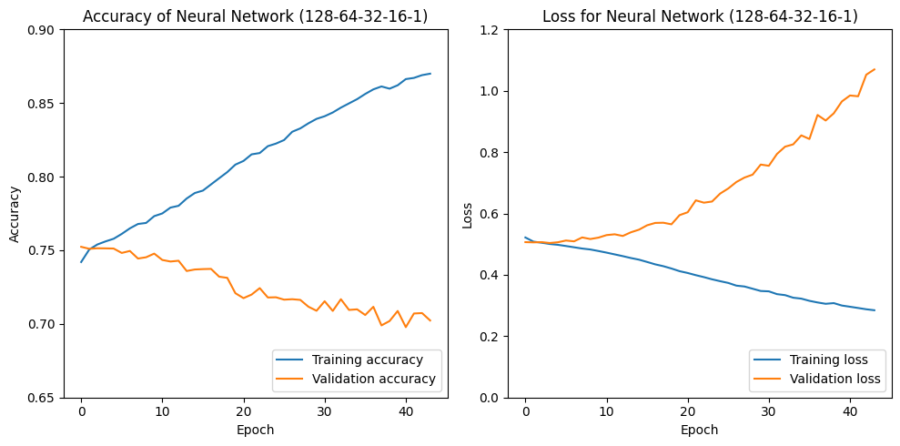

```python
import matplotlib.pyplot as plt

fig, axes = plt.subplots(1, 2, figsize=(10, 5))

axes[0].plot(history.history['accuracy'], label='Training accuracy')
axes[0].plot(history.history['val_accuracy'], label='Validation accuracy')
axes[0].set_title("Accuracy of Neural Network (128-64-32-16-1)")
axes[0].set_xlabel('Epoch')
axes[0].set_ylabel('Accuracy')
axes[0].set_ylim([0.65, 0.9])
axes[0].legend(loc='lower right')

axes[1].plot(history.history['loss'], label='Training loss')
axes[1].plot(history.history['val_loss'], label='Validation loss')
axes[1].set_title("Loss for Neural Network (128-64-32-16-1)")
axes[1].set_xlabel('Epoch')
axes[1].set_ylabel('Loss')
axes[1].set_ylim([0, 1.2])
axes[1].legend(loc='lower right')

plt.tight_layout()
plt.show()
```

### 6.3: The **(64-32-16-1)** architecture neural network

#### **Create the model**

```python
model_number = 3

model = Sequential()

model.add(Dense(64, activation='relu', input_shape=(X.shape[1],)))
model.add(Dense(32, activation='relu'))
model.add(Dense(16, activation='relu'))

model.add(Dense(1, activation='sigmoid'))
```

```python
model.summary()

# Used to create tabular data.
parameter_counts[model_number]  = model.count_params()
```

```
Model: "sequential_3"
```

```
┏━━━━━━━━━━━━━━━━━━━━━━━━━━━━━━━━━━━━━━┳━━━━━━━━━━━━━━━━━━━━━━━━━━━━━┳━━━━━━━━━━━━━━━━━┓
┃ Layer (type)                         ┃ Output Shape                ┃         Param # ┃
┡━━━━━━━━━━━━━━━━━━━━━━━━━━━━━━━━━━━━━━╇━━━━━━━━━━━━━━━━━━━━━━━━━━━━━╇━━━━━━━━━━━━━━━━━┩
│ dense_7 (Dense)                      │ (None, 64)                  │           1,408 │
├──────────────────────────────────────┼─────────────────────────────┼─────────────────┤
│ dense_8 (Dense)                      │ (None, 32)                  │           2,080 │
├──────────────────────────────────────┼─────────────────────────────┼─────────────────┤
│ dense_9 (Dense)                      │ (None, 16)                  │             528 │
├──────────────────────────────────────┼─────────────────────────────┼─────────────────┤
│ dense_10 (Dense)                     │ (None, 1)                   │              17 │
└──────────────────────────────────────┴─────────────────────────────┴─────────────────┘
```

```
 Total params: 4,033 (15.75 KB)
```

```
 Trainable params: 4,033 (15.75 KB)
```

```
 Non-trainable params: 0 (0.00 B)
```

#### **Compile and run the model**

```python
model.compile(loss='binary_crossentropy', optimizer = 'rmsprop', metrics=['accuracy','recall'])
callback_a = ModelCheckpoint(filepath = 'my_best_model.weights.h5', monitor='val_loss', save_best_only = True, save_weights_only = True, verbose = 1)
callback_b = EarlyStopping(monitor='val_loss', mode='min', patience=40, verbose=1)


history = model.fit(X_training, Y_training, validation_data=(X_validation, Y_validation), epochs=200,
                           batch_size=16, callbacks = [callback_a, callback_b])
```

```
1314/1326 ━━━━━━━━━━━━━━━━━━━━ 0s 2ms/step - accuracy: 0.7212 - loss: 0.5520 - recall: 0.7299
Epoch 1: val_loss improved from inf to 0.51249, saving model to my_best_model.weights.h5
1326/1326 ━━━━━━━━━━━━━━━━━━━━ 9s 5ms/step - accuracy: 0.7214 - loss: 0.5517 - recall: 0.7304 - val_accuracy: 0.7488 - val_loss: 0.5125 - val_recall: 0.7444
1309/1326 ━━━━━━━━━━━━━━━━━━━━ 0s 3ms/step - accuracy: 0.7532 - loss: 0.5045 - recall: 0.8039
Epoch 2: val_loss improved from 0.51249 to 0.50535, saving model to my_best_model.weights.h5
1326/1326 ━━━━━━━━━━━━━━━━━━━━ 8s 6ms/step - accuracy: 0.7532 - loss: 0.5046 - recall: 0.8039 - val_accuracy: 0.7527 - val_loss: 0.5053 - val_recall: 0.7854
1304/1326 ━━━━━━━━━━━━━━━━━━━━ 0s 2ms/step - accuracy: 0.7568 - loss: 0.4995 - recall: 0.7962
Epoch 3: val_loss improved from 0.50535 to 0.50448, saving model to my_best_model.weights.h5
1326/1326 ━━━━━━━━━━━━━━━━━━━━ 15s 10ms/step - accuracy: 0.7568 - loss: 0.4996 - recall: 0.7963 - val_accuracy: 0.7517 - val_loss: 0.5045 - val_recall: 0.7999
1316/1326 ━━━━━━━━━━━━━━━━━━━━ 0s 2ms/step - accuracy: 0.7598 - loss: 0.4986 - recall: 0.8051
Epoch 4: val_loss did not improve from 0.50448
1326/1326 ━━━━━━━━━━━━━━━━━━━━ 8s 6ms/step - accuracy: 0.7597 - loss: 0.4986 - recall: 0.8051 - val_accuracy: 0.7484 - val_loss: 0.5068 - val_recall: 0.7689
1317/1326 ━━━━━━━━━━━━━━━━━━━━ 0s 2ms/step - accuracy: 0.7576 - loss: 0.4962 - recall: 0.7911
Epoch 5: val_loss did not improve from 0.50448
1326/1326 ━━━━━━━━━━━━━━━━━━━━ 9s 5ms/step - accuracy: 0.7576 - loss: 0.4962 - recall: 0.7911 - val_accuracy: 0.7492 - val_loss: 0.5111 - val_recall: 0.8415
1325/1326 ━━━━━━━━━━━━━━━━━━━━ 0s 3ms/step - accuracy: 0.7577 - loss: 0.4954 - recall: 0.8013
Epoch 6: val_loss did not improve from 0.50448
1326/1326 ━━━━━━━━━━━━━━━━━━━━ 8s 6ms/step - accuracy: 0.7577 - loss: 0.4954 - recall: 0.8013 - val_accuracy: 0.7482 - val_loss: 0.5069 - val_recall: 0.7900
1302/1326 ━━━━━━━━━━━━━━━━━━━━ 0s 2ms/step - accuracy: 0.7618 - loss: 0.4895 - recall: 0.8082
Epoch 7: val_loss did not improve from 0.50448
1326/1326 ━━━━━━━━━━━━━━━━━━━━ 9s 5ms/step - accuracy: 0.7617 - loss: 0.4896 - recall: 0.8081 - val_accuracy: 0.7500 - val_loss: 0.5090 - val_recall: 0.8066
1324/1326 ━━━━━━━━━━━━━━━━━━━━ 0s 3ms/step - accuracy: 0.7639 - loss: 0.4905 - recall: 0.7981
Epoch 8: val_loss did not improve from 0.50448
1326/1326 ━━━━━━━━━━━━━━━━━━━━ 9s 7ms/step - accuracy: 0.7639 - loss: 0.4905 - recall: 0.7981 - val_accuracy: 0.7481 - val_loss: 0.5146 - val_recall: 0.8239
1310/1326 ━━━━━━━━━━━━━━━━━━━━ 0s 2ms/step - accuracy: 0.7630 - loss: 0.4838 - recall: 0.8069
Epoch 9: val_loss did not improve from 0.50448
1326/1326 ━━━━━━━━━━━━━━━━━━━━ 9s 6ms/step - accuracy: 0.7630 - loss: 0.4839 - recall: 0.8069 - val_accuracy: 0.7483 - val_loss: 0.5103 - val_recall: 0.7812
1326/1326 ━━━━━━━━━━━━━━━━━━━━ 0s 2ms/step - accuracy: 0.7647 - loss: 0.4844 - recall: 0.7971
Epoch 10: val_loss did not improve from 0.50448
1326/1326 ━━━━━━━━━━━━━━━━━━━━ 9s 5ms/step - accuracy: 0.7647 - loss: 0.4844 - recall: 0.7971 - val_accuracy: 0.7458 - val_loss: 0.5128 - val_recall: 0.7861
1313/1326 ━━━━━━━━━━━━━━━━━━━━ 0s 2ms/step - accuracy: 0.7706 - loss: 0.4859 - recall: 0.8046
Epoch 11: val_loss did not improve from 0.50448
1326/1326 ━━━━━━━━━━━━━━━━━━━━ 11s 5ms/step - accuracy: 0.7706 - loss: 0.4859 - recall: 0.8046 - val_accuracy: 0.7441 - val_loss: 0.5181 - val_recall: 0.8268
1315/1326 ━━━━━━━━━━━━━━━━━━━━ 0s 2ms/step - accuracy: 0.7716 - loss: 0.4743 - recall: 0.8080
Epoch 12: val_loss did not improve from 0.50448
1326/1326 ━━━━━━━━━━━━━━━━━━━━ 8s 6ms/step - accuracy: 0.7716 - loss: 0.4744 - recall: 0.8079 - val_accuracy: 0.7444 - val_loss: 0.5149 - val_recall: 0.8004
1316/1326 ━━━━━━━━━━━━━━━━━━━━ 0s 2ms/step - accuracy: 0.7695 - loss: 0.4778 - recall: 0.8033
Epoch 13: val_loss did not improve from 0.50448
1326/1326 ━━━━━━━━━━━━━━━━━━━━ 10s 6ms/step - accuracy: 0.7695 - loss: 0.4778 - recall: 0.8034 - val_accuracy: 0.7444 - val_loss: 0.5170 - val_recall: 0.7699
1326/1326 ━━━━━━━━━━━━━━━━━━━━ 0s 3ms/step - accuracy: 0.7794 - loss: 0.4699 - recall: 0.8205
```

[output cut: 75 more lines]

```
Epoch 39: val_loss did not improve from 0.50448
1326/1326 ━━━━━━━━━━━━━━━━━━━━ 12s 6ms/step - accuracy: 0.8091 - loss: 0.4133 - recall: 0.8271 - val_accuracy: 0.7235 - val_loss: 0.5923 - val_recall: 0.7709
1322/1326 ━━━━━━━━━━━━━━━━━━━━ 0s 3ms/step - accuracy: 0.8086 - loss: 0.4109 - recall: 0.8305
Epoch 40: val_loss did not improve from 0.50448
1326/1326 ━━━━━━━━━━━━━━━━━━━━ 11s 7ms/step - accuracy: 0.8086 - loss: 0.4110 - recall: 0.8305 - val_accuracy: 0.7245 - val_loss: 0.5888 - val_recall: 0.7496
1326/1326 ━━━━━━━━━━━━━━━━━━━━ 0s 3ms/step - accuracy: 0.8076 - loss: 0.4082 - recall: 0.8284
Epoch 41: val_loss did not improve from 0.50448
1326/1326 ━━━━━━━━━━━━━━━━━━━━ 10s 7ms/step - accuracy: 0.8076 - loss: 0.4082 - recall: 0.8283 - val_accuracy: 0.7264 - val_loss: 0.5989 - val_recall: 0.7346
1300/1326 ━━━━━━━━━━━━━━━━━━━━ 0s 2ms/step - accuracy: 0.8126 - loss: 0.4090 - recall: 0.8319
Epoch 42: val_loss did not improve from 0.50448
1326/1326 ━━━━━━━━━━━━━━━━━━━━ 8s 5ms/step - accuracy: 0.8125 - loss: 0.4091 - recall: 0.8318 - val_accuracy: 0.7256 - val_loss: 0.6049 - val_recall: 0.7643
1318/1326 ━━━━━━━━━━━━━━━━━━━━ 0s 3ms/step - accuracy: 0.8082 - loss: 0.4063 - recall: 0.8282
Epoch 43: val_loss did not improve from 0.50448
1326/1326 ━━━━━━━━━━━━━━━━━━━━ 12s 6ms/step - accuracy: 0.8082 - loss: 0.4063 - recall: 0.8282 - val_accuracy: 0.7251 - val_loss: 0.6124 - val_recall: 0.7769
Epoch 43: early stopping
```

#### **Evaluate the model**

```python
model.load_weights('my_best_model.weights.h5')
```

```python
train_scores = model.evaluate(X_training, Y_training)
val_scores = model.evaluate(X_validation, Y_validation)
```

```
663/663 ━━━━━━━━━━━━━━━━━━━━ 1s 2ms/step - accuracy: 0.7597 - loss: 0.4943 - recall: 0.8110
1547/1547 ━━━━━━━━━━━━━━━━━━━━ 3s 2ms/step - accuracy: 0.7493 - loss: 0.5069 - recall: 0.7950
```

```python
prediction_train= model.predict(X_training)
prediction_val = model.predict(X_validation)
```

```
663/663 ━━━━━━━━━━━━━━━━━━━━ 2s 2ms/step
1547/1547 ━━━━━━━━━━━━━━━━━━━━ 2s 1ms/step
```

```python
# For training and validation accuracy.
training_accuracies[model_number] = (accuracy_score(Y_training, prediction_train.round())) * 100
validation_accuracies[model_number] = (accuracy_score(Y_validation, prediction_val.round())) * 100
train_acc = training_accuracies[model_number]
val_acc = validation_accuracies[model_number]

# For training and validation loss.
training_losses[model_number] = train_scores[0]
validation_losses[model_number] = val_scores[0]
train_loss = training_losses[model_number]
val_loss = validation_losses[model_number]

# For training and validation recall.
training_recalls[model_number] = recall_score(Y_training, prediction_train.round())
validation_recalls[model_number] = recall_score(Y_validation, prediction_val.round())
train_recall = training_recalls[model_number]
val_recall = validation_recalls[model_number]

# For training and validation F1-score.
training_f1_scores[model_number] = f1_score(Y_training, prediction_train.round())
validation_f1_scores[model_number] = f1_score(Y_validation, prediction_val.round())
train_f1_score = training_f1_scores[model_number]
val_f1_score = validation_f1_scores[model_number]

# For training and validation AUC-ROC score.
training_roc_auc_scores[model_number] = roc_auc_score(Y_training, prediction_train.round())
validation_roc_auc_scores[model_number] = roc_auc_score(Y_validation, prediction_val.round())
train_roc_auc = training_roc_auc_scores[model_number]
val_roc_auc = validation_roc_auc_scores[model_number]

# For epoch count.
epoch_counts[model_number] = len(history.history['loss'])
epochs = epoch_counts[model_number]

print("\t\tTraining\tValidation")
print(f"Accuracy: \t{train_acc.item():.2f}% \t\t{val_acc.item():.2f}%")
print(f"Loss: \t\t{train_loss.item():.4f}\t\t{val_loss.item():.4f}")
print(f"Recall: \t{train_recall.item():.4f} \t\t{val_recall.item():.4f}")
print(f"F1-score: \t{train_f1_score.item():.4f} \t\t{val_f1_score.item():.4f}")
print(f"AUC-ROC score: \t{train_roc_auc.item():.4f} \t\t{train_roc_auc.item():.4f}")

print("\nPredictions:", prediction_val[0:10].T.round())
print("Number of epochs ran:\t", epochs.item())
```

```
		Training	Validation
Accuracy: 	75.96% 		75.17%
Loss: 		0.4959		0.5045
Recall: 	0.8088 		0.7999
F1-score: 	0.7714 		0.7629
AUC-ROC score: 	0.7595 		0.7595

Predictions: [[0. 1. 1. 1. 0. 0. 1. 1. 1. 0.]]
Number of epochs ran:	 43
```

#### **Visualize the model's results**

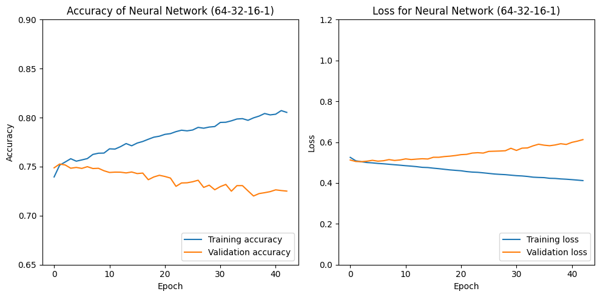

```python
import matplotlib.pyplot as plt

fig, axes = plt.subplots(1, 2, figsize=(10, 5))

axes[0].plot(history.history['accuracy'], label='Training accuracy')
axes[0].plot(history.history['val_accuracy'], label='Validation accuracy')
axes[0].set_title("Accuracy of Neural Network (64-32-16-1)")
axes[0].set_xlabel('Epoch')
axes[0].set_ylabel('Accuracy')
axes[0].set_ylim([0.65, 0.9])
axes[0].legend(loc='lower right')

axes[1].plot(history.history['loss'], label='Training loss')
axes[1].plot(history.history['val_loss'], label='Validation loss')
axes[1].set_title("Loss for Neural Network (64-32-16-1)")
axes[1].set_xlabel('Epoch')
axes[1].set_ylabel('Loss')
axes[1].set_ylim([0.0, 1.2])
axes[1].legend(loc='lower right')

plt.tight_layout()
plt.show()
```

### 6.4: The **(16-8-4-1)** architecture neural network

#### **Create the model**

```python
model_number = 4

model = Sequential()

model.add(Dense(16, activation='relu', input_shape=(X.shape[1],)))
model.add(Dense(8, activation='relu'))
model.add(Dense(4, activation='relu'))

model.add(Dense(1, activation='sigmoid'))
```

```python
model.summary()

# Used to create tabular data.
parameter_counts[model_number]  = model.count_params()
```

```
Model: "sequential_5"
```

```
┏━━━━━━━━━━━━━━━━━━━━━━━━━━━━━━━━━━━━━━┳━━━━━━━━━━━━━━━━━━━━━━━━━━━━━┳━━━━━━━━━━━━━━━━━┓
┃ Layer (type)                         ┃ Output Shape                ┃         Param # ┃
┡━━━━━━━━━━━━━━━━━━━━━━━━━━━━━━━━━━━━━━╇━━━━━━━━━━━━━━━━━━━━━━━━━━━━━╇━━━━━━━━━━━━━━━━━┩
│ dense_15 (Dense)                     │ (None, 16)                  │             352 │
├──────────────────────────────────────┼─────────────────────────────┼─────────────────┤
│ dense_16 (Dense)                     │ (None, 8)                   │             136 │
├──────────────────────────────────────┼─────────────────────────────┼─────────────────┤
│ dense_17 (Dense)                     │ (None, 4)                   │              36 │
├──────────────────────────────────────┼─────────────────────────────┼─────────────────┤
│ dense_18 (Dense)                     │ (None, 1)                   │               5 │
└──────────────────────────────────────┴─────────────────────────────┴─────────────────┘
```

```
 Total params: 529 (2.07 KB)
```

```
 Trainable params: 529 (2.07 KB)
```

```
 Non-trainable params: 0 (0.00 B)
```

#### **Compile and run the model**

```python
model.compile(loss='binary_crossentropy', optimizer = 'rmsprop', metrics=['accuracy','recall'])
callback_a = ModelCheckpoint(filepath = 'my_best_model.weights.h5', monitor='val_loss', save_best_only = True, save_weights_only = True, verbose = 1)
callback_b = EarlyStopping(monitor='val_loss', mode='min', patience=40, verbose=1)


history = model.fit(X_training, Y_training, validation_data=(X_validation, Y_validation), epochs=200,
                           batch_size=16, callbacks = [callback_a, callback_b])
```

```
1310/1326 ━━━━━━━━━━━━━━━━━━━━ 0s 2ms/step - accuracy: 0.6947 - loss: 0.5778 - recall: 0.7308
Epoch 1: val_loss improved from inf to 0.51428, saving model to my_best_model.weights.h5
1326/1326 ━━━━━━━━━━━━━━━━━━━━ 10s 6ms/step - accuracy: 0.6951 - loss: 0.5773 - recall: 0.7313 - val_accuracy: 0.7460 - val_loss: 0.5143 - val_recall: 0.8065
1299/1326 ━━━━━━━━━━━━━━━━━━━━ 0s 2ms/step - accuracy: 0.7473 - loss: 0.5129 - recall: 0.8104
Epoch 2: val_loss improved from 0.51428 to 0.50907, saving model to my_best_model.weights.h5
1326/1326 ━━━━━━━━━━━━━━━━━━━━ 8s 6ms/step - accuracy: 0.7472 - loss: 0.5130 - recall: 0.8103 - val_accuracy: 0.7492 - val_loss: 0.5091 - val_recall: 0.7992
1308/1326 ━━━━━━━━━━━━━━━━━━━━ 0s 2ms/step - accuracy: 0.7491 - loss: 0.5106 - recall: 0.7942
Epoch 3: val_loss improved from 0.50907 to 0.50778, saving model to my_best_model.weights.h5
1326/1326 ━━━━━━━━━━━━━━━━━━━━ 10s 6ms/step - accuracy: 0.7490 - loss: 0.5107 - recall: 0.7942 - val_accuracy: 0.7494 - val_loss: 0.5078 - val_recall: 0.8249
1319/1326 ━━━━━━━━━━━━━━━━━━━━ 0s 3ms/step - accuracy: 0.7523 - loss: 0.5087 - recall: 0.8033
Epoch 4: val_loss improved from 0.50778 to 0.50603, saving model to my_best_model.weights.h5
1326/1326 ━━━━━━━━━━━━━━━━━━━━ 12s 7ms/step - accuracy: 0.7522 - loss: 0.5088 - recall: 0.8033 - val_accuracy: 0.7505 - val_loss: 0.5060 - val_recall: 0.8003
1304/1326 ━━━━━━━━━━━━━━━━━━━━ 0s 2ms/step - accuracy: 0.7503 - loss: 0.5097 - recall: 0.8019
Epoch 5: val_loss improved from 0.50603 to 0.50593, saving model to my_best_model.weights.h5
1326/1326 ━━━━━━━━━━━━━━━━━━━━ 9s 6ms/step - accuracy: 0.7503 - loss: 0.5097 - recall: 0.8019 - val_accuracy: 0.7507 - val_loss: 0.5059 - val_recall: 0.8097
1300/1326 ━━━━━━━━━━━━━━━━━━━━ 0s 2ms/step - accuracy: 0.7528 - loss: 0.5095 - recall: 0.8108
Epoch 6: val_loss did not improve from 0.50593
1326/1326 ━━━━━━━━━━━━━━━━━━━━ 8s 5ms/step - accuracy: 0.7528 - loss: 0.5094 - recall: 0.8107 - val_accuracy: 0.7503 - val_loss: 0.5064 - val_recall: 0.7720
1321/1326 ━━━━━━━━━━━━━━━━━━━━ 0s 2ms/step - accuracy: 0.7564 - loss: 0.5028 - recall: 0.8013
Epoch 7: val_loss improved from 0.50593 to 0.50559, saving model to my_best_model.weights.h5
1326/1326 ━━━━━━━━━━━━━━━━━━━━ 8s 6ms/step - accuracy: 0.7564 - loss: 0.5029 - recall: 0.8013 - val_accuracy: 0.7507 - val_loss: 0.5056 - val_recall: 0.8042
1306/1326 ━━━━━━━━━━━━━━━━━━━━ 0s 2ms/step - accuracy: 0.7560 - loss: 0.5028 - recall: 0.8115
Epoch 8: val_loss did not improve from 0.50559
1326/1326 ━━━━━━━━━━━━━━━━━━━━ 8s 5ms/step - accuracy: 0.7559 - loss: 0.5028 - recall: 0.8114 - val_accuracy: 0.7496 - val_loss: 0.5062 - val_recall: 0.8066
1318/1326 ━━━━━━━━━━━━━━━━━━━━ 0s 4ms/step - accuracy: 0.7617 - loss: 0.4951 - recall: 0.8111
Epoch 9: val_loss did not improve from 0.50559
1326/1326 ━━━━━━━━━━━━━━━━━━━━ 9s 7ms/step - accuracy: 0.7616 - loss: 0.4951 - recall: 0.8111 - val_accuracy: 0.7497 - val_loss: 0.5064 - val_recall: 0.7958
1326/1326 ━━━━━━━━━━━━━━━━━━━━ 0s 2ms/step - accuracy: 0.7553 - loss: 0.4964 - recall: 0.8044
Epoch 10: val_loss did not improve from 0.50559
1326/1326 ━━━━━━━━━━━━━━━━━━━━ 6s 5ms/step - accuracy: 0.7553 - loss: 0.4964 - recall: 0.8044 - val_accuracy: 0.7498 - val_loss: 0.5061 - val_recall: 0.7908
1308/1326 ━━━━━━━━━━━━━━━━━━━━ 0s 4ms/step - accuracy: 0.7585 - loss: 0.4983 - recall: 0.8124
Epoch 11: val_loss did not improve from 0.50559
1326/1326 ━━━━━━━━━━━━━━━━━━━━ 10s 7ms/step - accuracy: 0.7585 - loss: 0.4983 - recall: 0.8124 - val_accuracy: 0.7497 - val_loss: 0.5071 - val_recall: 0.7875
1318/1326 ━━━━━━━━━━━━━━━━━━━━ 0s 2ms/step - accuracy: 0.7555 - loss: 0.5000 - recall: 0.8003
Epoch 12: val_loss did not improve from 0.50559
1326/1326 ━━━━━━━━━━━━━━━━━━━━ 8s 6ms/step - accuracy: 0.7555 - loss: 0.5000 - recall: 0.8004 - val_accuracy: 0.7494 - val_loss: 0.5079 - val_recall: 0.8137
1324/1326 ━━━━━━━━━━━━━━━━━━━━ 0s 2ms/step - accuracy: 0.7578 - loss: 0.4963 - recall: 0.8103
Epoch 13: val_loss did not improve from 0.50559
1326/1326 ━━━━━━━━━━━━━━━━━━━━ 10s 6ms/step - accuracy: 0.7578 - loss: 0.4963 - recall: 0.8103 - val_accuracy: 0.7495 - val_loss: 0.5073 - val_recall: 0.8004
1321/1326 ━━━━━━━━━━━━━━━━━━━━ 0s 2ms/step - accuracy: 0.7580 - loss: 0.4995 - recall: 0.8058
```

[output cut: 87 more lines]

```
Epoch 43: val_loss did not improve from 0.50559
1326/1326 ━━━━━━━━━━━━━━━━━━━━ 9s 7ms/step - accuracy: 0.7625 - loss: 0.4911 - recall: 0.8097 - val_accuracy: 0.7464 - val_loss: 0.5149 - val_recall: 0.7850
1324/1326 ━━━━━━━━━━━━━━━━━━━━ 0s 2ms/step - accuracy: 0.7597 - loss: 0.4945 - recall: 0.8080
Epoch 44: val_loss did not improve from 0.50559
1326/1326 ━━━━━━━━━━━━━━━━━━━━ 10s 6ms/step - accuracy: 0.7597 - loss: 0.4945 - recall: 0.8080 - val_accuracy: 0.7467 - val_loss: 0.5163 - val_recall: 0.8047
1305/1326 ━━━━━━━━━━━━━━━━━━━━ 0s 2ms/step - accuracy: 0.7665 - loss: 0.4870 - recall: 0.8093
Epoch 45: val_loss did not improve from 0.50559
1326/1326 ━━━━━━━━━━━━━━━━━━━━ 8s 5ms/step - accuracy: 0.7664 - loss: 0.4871 - recall: 0.8093 - val_accuracy: 0.7464 - val_loss: 0.5139 - val_recall: 0.7947
1308/1326 ━━━━━━━━━━━━━━━━━━━━ 0s 3ms/step - accuracy: 0.7689 - loss: 0.4869 - recall: 0.8121
Epoch 46: val_loss did not improve from 0.50559
1326/1326 ━━━━━━━━━━━━━━━━━━━━ 11s 6ms/step - accuracy: 0.7689 - loss: 0.4870 - recall: 0.8121 - val_accuracy: 0.7455 - val_loss: 0.5138 - val_recall: 0.7780
1319/1326 ━━━━━━━━━━━━━━━━━━━━ 0s 2ms/step - accuracy: 0.7648 - loss: 0.4928 - recall: 0.8125
Epoch 47: val_loss did not improve from 0.50559
1326/1326 ━━━━━━━━━━━━━━━━━━━━ 8s 6ms/step - accuracy: 0.7648 - loss: 0.4928 - recall: 0.8125 - val_accuracy: 0.7458 - val_loss: 0.5152 - val_recall: 0.7974
Epoch 47: early stopping
```

#### **Evaluate the model**

```python
model.load_weights('my_best_model.weights.h5')
```

```python
train_scores = model.evaluate(X_training, Y_training)
val_scores = model.evaluate(X_validation, Y_validation)
```

```
663/663 ━━━━━━━━━━━━━━━━━━━━ 1s 2ms/step - accuracy: 0.7580 - loss: 0.4988 - recall: 0.8147
1547/1547 ━━━━━━━━━━━━━━━━━━━━ 3s 2ms/step - accuracy: 0.7477 - loss: 0.5084 - recall: 0.8004
```

```python
prediction_train= model.predict(X_training)
prediction_val = model.predict(X_validation)
```

```
663/663 ━━━━━━━━━━━━━━━━━━━━ 1s 2ms/step
1547/1547 ━━━━━━━━━━━━━━━━━━━━ 2s 1ms/step
```

```python
# For training and validation accuracy.
training_accuracies[model_number] = (accuracy_score(Y_training, prediction_train.round())) * 100
validation_accuracies[model_number] = (accuracy_score(Y_validation, prediction_val.round())) * 100
train_acc = training_accuracies[model_number]
val_acc = validation_accuracies[model_number]

# For training and validation loss.
training_losses[model_number] = train_scores[0]
validation_losses[model_number] = val_scores[0]
train_loss = training_losses[model_number]
val_loss = validation_losses[model_number]

# For training and validation recall.
training_recalls[model_number] = recall_score(Y_training, prediction_train.round())
validation_recalls[model_number] = recall_score(Y_validation, prediction_val.round())
train_recall = training_recalls[model_number]
val_recall = validation_recalls[model_number]

# For training and validation F1-score.
training_f1_scores[model_number] = f1_score(Y_training, prediction_train.round())
validation_f1_scores[model_number] = f1_score(Y_validation, prediction_val.round())
train_f1_score = training_f1_scores[model_number]
val_f1_score = validation_f1_scores[model_number]

# For training and validation AUC-ROC score.
training_roc_auc_scores[model_number] = roc_auc_score(Y_training, prediction_train.round())
validation_roc_auc_scores[model_number] = roc_auc_score(Y_validation, prediction_val.round())
train_roc_auc = training_roc_auc_scores[model_number]
val_roc_auc = validation_roc_auc_scores[model_number]

# For epoch count.
epoch_counts[model_number] = len(history.history['loss'])
epochs = epoch_counts[model_number]

print("\t\tTraining\tValidation")
print(f"Accuracy: \t{train_acc.item():.2f}% \t\t{val_acc.item():.2f}%")
print(f"Loss: \t\t{train_loss.item():.4f}\t\t{val_loss.item():.4f}")
print(f"Recall: \t{train_recall.item():.4f} \t\t{val_recall.item():.4f}")
print(f"F1-score: \t{train_f1_score.item():.4f} \t\t{val_f1_score.item():.4f}")
print(f"AUC-ROC score: \t{train_roc_auc.item():.4f} \t\t{train_roc_auc.item():.4f}")

print("\nPredictions:", prediction_val[0:10].T.round())
print("Number of epochs ran:\t", epochs.item())
```

```
		Training	Validation
Accuracy: 	75.61% 		75.07%
Loss: 		0.5001		0.5056
Recall: 	0.8102 		0.8042
F1-score: 	0.7691 		0.7631
AUC-ROC score: 	0.7560 		0.7560

Predictions: [[0. 0. 1. 1. 0. 0. 1. 1. 0. 0.]]
Number of epochs ran:	 47
```

#### **Visualize the model's results**

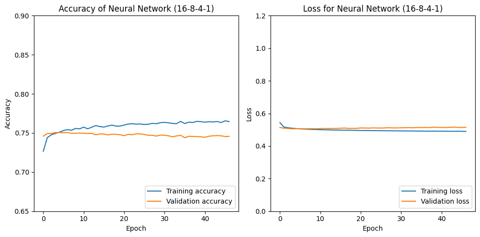

```python
import matplotlib.pyplot as plt

fig, axes = plt.subplots(1, 2, figsize=(10, 5))

axes[0].plot(history.history['accuracy'], label='Training accuracy')
axes[0].plot(history.history['val_accuracy'], label='Validation accuracy')
axes[0].set_title("Accuracy of Neural Network (16-8-4-1)")
axes[0].set_xlabel('Epoch')
axes[0].set_ylabel('Accuracy')
axes[0].set_ylim([0.65, 0.9])
axes[0].legend(loc='lower right')

axes[1].plot(history.history['loss'], label='Training loss')
axes[1].plot(history.history['val_loss'], label='Validation loss')
axes[1].set_title("Loss for Neural Network (16-8-4-1)")
axes[1].set_xlabel('Epoch')
axes[1].set_ylabel('Loss')
axes[1].set_ylim([0, 1.2])
axes[1].legend(loc='lower right')

plt.tight_layout()
plt.show()
```

### 6.5: **The (16-8-1)** architecture neural network

#### **Create the model**

```python
model_number = 5

model = Sequential()

model.add(Dense(16, activation= 'relu', input_shape=(X.shape[1],)))
model.add(Dense(8, activation= 'relu'))

model.add(Dense(1, activation='sigmoid'))
```

```python
model.summary()

# Used to create tabular data.
parameter_counts[model_number]  = model.count_params()
```

```
Model: "sequential_8"
```

```
┏━━━━━━━━━━━━━━━━━━━━━━━━━━━━━━━━━━━━━━┳━━━━━━━━━━━━━━━━━━━━━━━━━━━━━┳━━━━━━━━━━━━━━━━━┓
┃ Layer (type)                         ┃ Output Shape                ┃         Param # ┃
┡━━━━━━━━━━━━━━━━━━━━━━━━━━━━━━━━━━━━━━╇━━━━━━━━━━━━━━━━━━━━━━━━━━━━━╇━━━━━━━━━━━━━━━━━┩
│ dense_25 (Dense)                     │ (None, 16)                  │             352 │
├──────────────────────────────────────┼─────────────────────────────┼─────────────────┤
│ dense_26 (Dense)                     │ (None, 8)                   │             136 │
├──────────────────────────────────────┼─────────────────────────────┼─────────────────┤
│ dense_27 (Dense)                     │ (None, 1)                   │               9 │
└──────────────────────────────────────┴─────────────────────────────┴─────────────────┘
```

```
 Total params: 497 (1.94 KB)
```

```
 Trainable params: 497 (1.94 KB)
```

```
 Non-trainable params: 0 (0.00 B)
```

#### **Compile and run the model**

```python
model.compile(loss='binary_crossentropy', optimizer = 'rmsprop', metrics=['accuracy','recall'])
callback_a = ModelCheckpoint(filepath = 'my_best_model.weights.h5', monitor='val_loss', save_best_only = True, save_weights_only = True, verbose = 1)
callback_b = EarlyStopping(monitor='val_loss', mode='min', patience=40, verbose=1)


history = model.fit(X_training, Y_training, validation_data=(X_validation, Y_validation), epochs=200,
                           batch_size=16, callbacks = [callback_a, callback_b])
```

```
1319/1326 ━━━━━━━━━━━━━━━━━━━━ 0s 2ms/step - accuracy: 0.7090 - loss: 0.5649 - recall: 0.7309
Epoch 1: val_loss improved from inf to 0.51519, saving model to my_best_model.weights.h5
1326/1326 ━━━━━━━━━━━━━━━━━━━━ 10s 6ms/step - accuracy: 0.7092 - loss: 0.5647 - recall: 0.7312 - val_accuracy: 0.7478 - val_loss: 0.5152 - val_recall: 0.7981
1301/1326 ━━━━━━━━━━━━━━━━━━━━ 0s 2ms/step - accuracy: 0.7436 - loss: 0.5204 - recall: 0.7954
Epoch 2: val_loss improved from 0.51519 to 0.51091, saving model to my_best_model.weights.h5
1326/1326 ━━━━━━━━━━━━━━━━━━━━ 8s 5ms/step - accuracy: 0.7437 - loss: 0.5204 - recall: 0.7955 - val_accuracy: 0.7491 - val_loss: 0.5109 - val_recall: 0.7855
1316/1326 ━━━━━━━━━━━━━━━━━━━━ 0s 2ms/step - accuracy: 0.7471 - loss: 0.5154 - recall: 0.8004
Epoch 3: val_loss improved from 0.51091 to 0.51060, saving model to my_best_model.weights.h5
1326/1326 ━━━━━━━━━━━━━━━━━━━━ 10s 4ms/step - accuracy: 0.7471 - loss: 0.5154 - recall: 0.8004 - val_accuracy: 0.7490 - val_loss: 0.5106 - val_recall: 0.8119
1314/1326 ━━━━━━━━━━━━━━━━━━━━ 0s 2ms/step - accuracy: 0.7558 - loss: 0.5039 - recall: 0.8105
Epoch 4: val_loss improved from 0.51060 to 0.50814, saving model to my_best_model.weights.h5
1326/1326 ━━━━━━━━━━━━━━━━━━━━ 8s 6ms/step - accuracy: 0.7557 - loss: 0.5039 - recall: 0.8104 - val_accuracy: 0.7508 - val_loss: 0.5081 - val_recall: 0.7998
1303/1326 ━━━━━━━━━━━━━━━━━━━━ 0s 2ms/step - accuracy: 0.7553 - loss: 0.5051 - recall: 0.8011
Epoch 5: val_loss improved from 0.50814 to 0.50738, saving model to my_best_model.weights.h5
1326/1326 ━━━━━━━━━━━━━━━━━━━━ 6s 5ms/step - accuracy: 0.7553 - loss: 0.5051 - recall: 0.8012 - val_accuracy: 0.7510 - val_loss: 0.5074 - val_recall: 0.8069
1313/1326 ━━━━━━━━━━━━━━━━━━━━ 0s 2ms/step - accuracy: 0.7528 - loss: 0.5066 - recall: 0.8083
Epoch 6: val_loss improved from 0.50738 to 0.50658, saving model to my_best_model.weights.h5
1326/1326 ━━━━━━━━━━━━━━━━━━━━ 12s 6ms/step - accuracy: 0.7528 - loss: 0.5066 - recall: 0.8083 - val_accuracy: 0.7515 - val_loss: 0.5066 - val_recall: 0.8041
1318/1326 ━━━━━━━━━━━━━━━━━━━━ 0s 2ms/step - accuracy: 0.7539 - loss: 0.5060 - recall: 0.8050
Epoch 7: val_loss did not improve from 0.50658
1326/1326 ━━━━━━━━━━━━━━━━━━━━ 10s 6ms/step - accuracy: 0.7539 - loss: 0.5060 - recall: 0.8050 - val_accuracy: 0.7504 - val_loss: 0.5074 - val_recall: 0.7896
1313/1326 ━━━━━━━━━━━━━━━━━━━━ 0s 2ms/step - accuracy: 0.7535 - loss: 0.5065 - recall: 0.8125
Epoch 8: val_loss did not improve from 0.50658
1326/1326 ━━━━━━━━━━━━━━━━━━━━ 10s 6ms/step - accuracy: 0.7535 - loss: 0.5065 - recall: 0.8125 - val_accuracy: 0.7523 - val_loss: 0.5069 - val_recall: 0.7990
1311/1326 ━━━━━━━━━━━━━━━━━━━━ 0s 2ms/step - accuracy: 0.7599 - loss: 0.5006 - recall: 0.8133
Epoch 9: val_loss did not improve from 0.50658
1326/1326 ━━━━━━━━━━━━━━━━━━━━ 8s 5ms/step - accuracy: 0.7598 - loss: 0.5006 - recall: 0.8132 - val_accuracy: 0.7517 - val_loss: 0.5067 - val_recall: 0.8058
1297/1326 ━━━━━━━━━━━━━━━━━━━━ 0s 3ms/step - accuracy: 0.7510 - loss: 0.5082 - recall: 0.8071
Epoch 10: val_loss did not improve from 0.50658
1326/1326 ━━━━━━━━━━━━━━━━━━━━ 13s 7ms/step - accuracy: 0.7511 - loss: 0.5081 - recall: 0.8071 - val_accuracy: 0.7518 - val_loss: 0.5068 - val_recall: 0.8168
1308/1326 ━━━━━━━━━━━━━━━━━━━━ 0s 2ms/step - accuracy: 0.7530 - loss: 0.5038 - recall: 0.8077
Epoch 11: val_loss improved from 0.50658 to 0.50622, saving model to my_best_model.weights.h5
1326/1326 ━━━━━━━━━━━━━━━━━━━━ 8s 6ms/step - accuracy: 0.7530 - loss: 0.5038 - recall: 0.8077 - val_accuracy: 0.7520 - val_loss: 0.5062 - val_recall: 0.8175
1319/1326 ━━━━━━━━━━━━━━━━━━━━ 0s 2ms/step - accuracy: 0.7592 - loss: 0.5006 - recall: 0.8219
Epoch 12: val_loss did not improve from 0.50622
1326/1326 ━━━━━━━━━━━━━━━━━━━━ 8s 5ms/step - accuracy: 0.7592 - loss: 0.5006 - recall: 0.8218 - val_accuracy: 0.7522 - val_loss: 0.5084 - val_recall: 0.7964
1317/1326 ━━━━━━━━━━━━━━━━━━━━ 0s 2ms/step - accuracy: 0.7584 - loss: 0.5019 - recall: 0.8052
Epoch 13: val_loss did not improve from 0.50622
1326/1326 ━━━━━━━━━━━━━━━━━━━━ 12s 6ms/step - accuracy: 0.7584 - loss: 0.5019 - recall: 0.8053 - val_accuracy: 0.7507 - val_loss: 0.5073 - val_recall: 0.7835
1322/1326 ━━━━━━━━━━━━━━━━━━━━ 0s 3ms/step - accuracy: 0.7584 - loss: 0.5009 - recall: 0.8071
```

[output cut: 99 more lines]

```
Epoch 47: val_loss did not improve from 0.50622
1326/1326 ━━━━━━━━━━━━━━━━━━━━ 12s 6ms/step - accuracy: 0.7621 - loss: 0.4953 - recall: 0.8179 - val_accuracy: 0.7478 - val_loss: 0.5116 - val_recall: 0.8104
1312/1326 ━━━━━━━━━━━━━━━━━━━━ 0s 3ms/step - accuracy: 0.7624 - loss: 0.4956 - recall: 0.8170
Epoch 48: val_loss did not improve from 0.50622
1326/1326 ━━━━━━━━━━━━━━━━━━━━ 10s 6ms/step - accuracy: 0.7624 - loss: 0.4956 - recall: 0.8170 - val_accuracy: 0.7487 - val_loss: 0.5119 - val_recall: 0.8076
1320/1326 ━━━━━━━━━━━━━━━━━━━━ 0s 2ms/step - accuracy: 0.7625 - loss: 0.4952 - recall: 0.8231
Epoch 49: val_loss did not improve from 0.50622
1326/1326 ━━━━━━━━━━━━━━━━━━━━ 6s 5ms/step - accuracy: 0.7625 - loss: 0.4952 - recall: 0.8231 - val_accuracy: 0.7488 - val_loss: 0.5126 - val_recall: 0.8048
1316/1326 ━━━━━━━━━━━━━━━━━━━━ 0s 3ms/step - accuracy: 0.7610 - loss: 0.4984 - recall: 0.8137
Epoch 50: val_loss did not improve from 0.50622
1326/1326 ━━━━━━━━━━━━━━━━━━━━ 8s 6ms/step - accuracy: 0.7610 - loss: 0.4984 - recall: 0.8137 - val_accuracy: 0.7475 - val_loss: 0.5111 - val_recall: 0.8090
1325/1326 ━━━━━━━━━━━━━━━━━━━━ 0s 2ms/step - accuracy: 0.7643 - loss: 0.4940 - recall: 0.8224
Epoch 51: val_loss did not improve from 0.50622
1326/1326 ━━━━━━━━━━━━━━━━━━━━ 15s 10ms/step - accuracy: 0.7642 - loss: 0.4940 - recall: 0.8224 - val_accuracy: 0.7472 - val_loss: 0.5115 - val_recall: 0.8161
Epoch 51: early stopping
```

#### **Evaluate the model**

```python
model.load_weights('my_best_model.weights.h5')
```

```python
train_scores = model.evaluate(X_training, Y_training)
val_scores = model.evaluate(X_validation, Y_validation)
```

```
663/663 ━━━━━━━━━━━━━━━━━━━━ 2s 2ms/step - accuracy: 0.7603 - loss: 0.4984 - recall: 0.8276
1547/1547 ━━━━━━━━━━━━━━━━━━━━ 2s 2ms/step - accuracy: 0.7499 - loss: 0.5083 - recall: 0.8140
```

```python
prediction_train= model.predict(X_training)
prediction_val = model.predict(X_validation)
```

```
663/663 ━━━━━━━━━━━━━━━━━━━━ 1s 1ms/step
1547/1547 ━━━━━━━━━━━━━━━━━━━━ 2s 1ms/step
```

```python
# For training and validation accuracy.
training_accuracies[model_number] = (accuracy_score(Y_training, prediction_train.round())) * 100
validation_accuracies[model_number] = (accuracy_score(Y_validation, prediction_val.round())) * 100
train_acc = training_accuracies[model_number]
val_acc = validation_accuracies[model_number]

# For training and validation loss.
training_losses[model_number] = train_scores[0]
validation_losses[model_number] = val_scores[0]
train_loss = training_losses[model_number]
val_loss = validation_losses[model_number]

# For training and validation recall.
training_recalls[model_number] = recall_score(Y_training, prediction_train.round())
validation_recalls[model_number] = recall_score(Y_validation, prediction_val.round())
train_recall = training_recalls[model_number]
val_recall = validation_recalls[model_number]

# For training and validation F1-score.
training_f1_scores[model_number] = f1_score(Y_training, prediction_train.round())
validation_f1_scores[model_number] = f1_score(Y_validation, prediction_val.round())
train_f1_score = training_f1_scores[model_number]
val_f1_score = validation_f1_scores[model_number]

# For training and validation AUC-ROC score.
training_roc_auc_scores[model_number] = roc_auc_score(Y_training, prediction_train.round())
validation_roc_auc_scores[model_number] = roc_auc_score(Y_validation, prediction_val.round())
train_roc_auc = training_roc_auc_scores[model_number]
val_roc_auc = validation_roc_auc_scores[model_number]

# For epoch count.
epoch_counts[model_number] = len(history.history['loss'])
epochs = epoch_counts[model_number]

print("\t\tTraining\tValidation")
print(f"Accuracy: \t{train_acc.item():.2f}% \t\t{val_acc.item():.2f}%")
print(f"Loss: \t\t{train_loss.item():.4f}\t\t{val_loss.item():.4f}")
print(f"Recall: \t{train_recall.item():.4f} \t\t{val_recall.item():.4f}")
print(f"F1-score: \t{train_f1_score.item():.4f} \t\t{val_f1_score.item():.4f}")
print(f"AUC-ROC score: \t{train_roc_auc.item():.4f} \t\t{train_roc_auc.item():.4f}")

print("\nPredictions:", prediction_val[0:10].T.round())
print("Number of epochs ran:\t", epochs.item())
```

```
		Training	Validation
Accuracy: 	75.86% 		75.20%
Loss: 		0.4997		0.5062
Recall: 	0.8242 		0.8175
F1-score: 	0.7740 		0.7671
AUC-ROC score: 	0.7584 		0.7584

Predictions: [[0. 1. 1. 1. 0. 0. 1. 1. 1. 0.]]
Number of epochs ran:	 51
```

#### **Visualize the model's results**

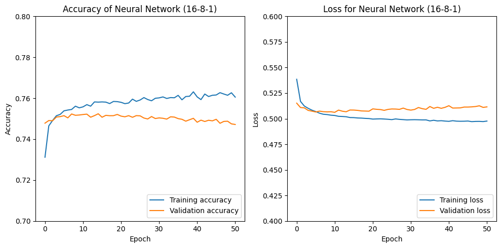

```python
import matplotlib.pyplot as plt

fig, axes = plt.subplots(1, 2, figsize=(10, 5))

axes[0].plot(history.history['accuracy'], label='Training accuracy')
axes[0].plot(history.history['val_accuracy'], label='Validation accuracy')
axes[0].set_title("Accuracy of Neural Network (16-8-1)")
axes[0].set_xlabel('Epoch')
axes[0].set_ylabel('Accuracy')
axes[0].set_ylim([0.7, 0.8])
axes[0].legend(loc='lower right')

axes[1].plot(history.history['loss'], label='Training loss')
axes[1].plot(history.history['val_loss'], label='Validation loss')
axes[1].set_title("Loss for Neural Network (16-8-1)")
axes[1].set_xlabel('Epoch')
axes[1].set_ylabel('Loss')
axes[1].set_ylim([0.4, 0.6])
axes[1].legend(loc='lower right')

plt.tight_layout()
plt.show()
```

### 6.6: The **(4-1)** architecture neural network

#### **Create the model**

```python
model_number = 6
model = Sequential()

model.add(Dense(4, activation='relu', input_shape=(X.shape[1],)))
model.add(Dense(1, activation='sigmoid'))
```

```python
model.summary()

# Used to create tabular data.
parameter_counts[model_number] = model.count_params()
```

```
Model: "sequential_9"
```

```
┏━━━━━━━━━━━━━━━━━━━━━━━━━━━━━━━━━━━━━━┳━━━━━━━━━━━━━━━━━━━━━━━━━━━━━┳━━━━━━━━━━━━━━━━━┓
┃ Layer (type)                         ┃ Output Shape                ┃         Param # ┃
┡━━━━━━━━━━━━━━━━━━━━━━━━━━━━━━━━━━━━━━╇━━━━━━━━━━━━━━━━━━━━━━━━━━━━━╇━━━━━━━━━━━━━━━━━┩
│ dense_28 (Dense)                     │ (None, 4)                   │              88 │
├──────────────────────────────────────┼─────────────────────────────┼─────────────────┤
│ dense_29 (Dense)                     │ (None, 1)                   │               5 │
└──────────────────────────────────────┴─────────────────────────────┴─────────────────┘
```

```
 Total params: 93 (372.00 B)
```

```
 Trainable params: 93 (372.00 B)
```

```
 Non-trainable params: 0 (0.00 B)
```

#### **Compile and run the model**

```python
model.compile(loss='binary_crossentropy', optimizer = 'rmsprop', metrics=['accuracy','recall'])
callback_a = ModelCheckpoint(filepath = 'my_best_model.weights.h5', monitor='val_loss', save_best_only = True, save_weights_only = True, verbose = 1)
callback_b = EarlyStopping(monitor='val_loss', mode='min', patience=40, verbose=1)


history = model.fit(X_training, Y_training, validation_data=(X_validation, Y_validation), epochs=200,
                           batch_size=16, callbacks = [callback_a, callback_b])
```

```
1319/1326 ━━━━━━━━━━━━━━━━━━━━ 0s 4ms/step - accuracy: 0.6591 - loss: 0.6449 - recall: 0.5736
Epoch 1: val_loss improved from inf to 0.53022, saving model to my_best_model.weights.h5
1326/1326 ━━━━━━━━━━━━━━━━━━━━ 13s 8ms/step - accuracy: 0.6594 - loss: 0.6445 - recall: 0.5744 - val_accuracy: 0.7391 - val_loss: 0.5302 - val_recall: 0.7935
1298/1326 ━━━━━━━━━━━━━━━━━━━━ 0s 2ms/step - accuracy: 0.7445 - loss: 0.5272 - recall: 0.8042
Epoch 2: val_loss improved from 0.53022 to 0.51609, saving model to my_best_model.weights.h5
1326/1326 ━━━━━━━━━━━━━━━━━━━━ 7s 6ms/step - accuracy: 0.7445 - loss: 0.5272 - recall: 0.8043 - val_accuracy: 0.7454 - val_loss: 0.5161 - val_recall: 0.8151
1304/1326 ━━━━━━━━━━━━━━━━━━━━ 0s 2ms/step - accuracy: 0.7452 - loss: 0.5192 - recall: 0.8089
Epoch 3: val_loss improved from 0.51609 to 0.51239, saving model to my_best_model.weights.h5
1326/1326 ━━━━━━━━━━━━━━━━━━━━ 10s 6ms/step - accuracy: 0.7452 - loss: 0.5191 - recall: 0.8089 - val_accuracy: 0.7476 - val_loss: 0.5124 - val_recall: 0.8222
1324/1326 ━━━━━━━━━━━━━━━━━━━━ 0s 2ms/step - accuracy: 0.7513 - loss: 0.5141 - recall: 0.8189
Epoch 4: val_loss improved from 0.51239 to 0.50979, saving model to my_best_model.weights.h5
1326/1326 ━━━━━━━━━━━━━━━━━━━━ 9s 4ms/step - accuracy: 0.7513 - loss: 0.5141 - recall: 0.8189 - val_accuracy: 0.7502 - val_loss: 0.5098 - val_recall: 0.8139
1298/1326 ━━━━━━━━━━━━━━━━━━━━ 0s 2ms/step - accuracy: 0.7555 - loss: 0.5061 - recall: 0.8156
Epoch 5: val_loss improved from 0.50979 to 0.50837, saving model to my_best_model.weights.h5
1326/1326 ━━━━━━━━━━━━━━━━━━━━ 7s 6ms/step - accuracy: 0.7554 - loss: 0.5062 - recall: 0.8154 - val_accuracy: 0.7509 - val_loss: 0.5084 - val_recall: 0.8143
1316/1326 ━━━━━━━━━━━━━━━━━━━━ 0s 2ms/step - accuracy: 0.7511 - loss: 0.5095 - recall: 0.8061
Epoch 6: val_loss improved from 0.50837 to 0.50715, saving model to my_best_model.weights.h5
1326/1326 ━━━━━━━━━━━━━━━━━━━━ 10s 6ms/step - accuracy: 0.7511 - loss: 0.5095 - recall: 0.8061 - val_accuracy: 0.7522 - val_loss: 0.5071 - val_recall: 0.8024
1318/1326 ━━━━━━━━━━━━━━━━━━━━ 0s 3ms/step - accuracy: 0.7454 - loss: 0.5163 - recall: 0.7964
Epoch 7: val_loss improved from 0.50715 to 0.50671, saving model to my_best_model.weights.h5
1326/1326 ━━━━━━━━━━━━━━━━━━━━ 9s 7ms/step - accuracy: 0.7454 - loss: 0.5162 - recall: 0.7965 - val_accuracy: 0.7515 - val_loss: 0.5067 - val_recall: 0.7965
1322/1326 ━━━━━━━━━━━━━━━━━━━━ 0s 2ms/step - accuracy: 0.7542 - loss: 0.5101 - recall: 0.8052
Epoch 8: val_loss improved from 0.50671 to 0.50642, saving model to my_best_model.weights.h5
1326/1326 ━━━━━━━━━━━━━━━━━━━━ 9s 6ms/step - accuracy: 0.7542 - loss: 0.5101 - recall: 0.8051 - val_accuracy: 0.7523 - val_loss: 0.5064 - val_recall: 0.7951
1304/1326 ━━━━━━━━━━━━━━━━━━━━ 0s 2ms/step - accuracy: 0.7505 - loss: 0.5105 - recall: 0.7978
Epoch 9: val_loss improved from 0.50642 to 0.50578, saving model to my_best_model.weights.h5
1326/1326 ━━━━━━━━━━━━━━━━━━━━ 8s 6ms/step - accuracy: 0.7505 - loss: 0.5105 - recall: 0.7979 - val_accuracy: 0.7525 - val_loss: 0.5058 - val_recall: 0.7975
1318/1326 ━━━━━━━━━━━━━━━━━━━━ 0s 3ms/step - accuracy: 0.7499 - loss: 0.5114 - recall: 0.7977
Epoch 10: val_loss did not improve from 0.50578
1326/1326 ━━━━━━━━━━━━━━━━━━━━ 11s 6ms/step - accuracy: 0.7499 - loss: 0.5114 - recall: 0.7977 - val_accuracy: 0.7524 - val_loss: 0.5065 - val_recall: 0.8071
1301/1326 ━━━━━━━━━━━━━━━━━━━━ 0s 2ms/step - accuracy: 0.7501 - loss: 0.5119 - recall: 0.7990
Epoch 11: val_loss improved from 0.50578 to 0.50509, saving model to my_best_model.weights.h5
1326/1326 ━━━━━━━━━━━━━━━━━━━━ 6s 4ms/step - accuracy: 0.7502 - loss: 0.5119 - recall: 0.7990 - val_accuracy: 0.7523 - val_loss: 0.5051 - val_recall: 0.7999
1307/1326 ━━━━━━━━━━━━━━━━━━━━ 0s 2ms/step - accuracy: 0.7508 - loss: 0.5089 - recall: 0.7997
Epoch 12: val_loss did not improve from 0.50509
1326/1326 ━━━━━━━━━━━━━━━━━━━━ 7s 6ms/step - accuracy: 0.7508 - loss: 0.5089 - recall: 0.7997 - val_accuracy: 0.7520 - val_loss: 0.5051 - val_recall: 0.8001
1301/1326 ━━━━━━━━━━━━━━━━━━━━ 0s 2ms/step - accuracy: 0.7528 - loss: 0.5046 - recall: 0.7992
Epoch 13: val_loss improved from 0.50509 to 0.50480, saving model to my_best_model.weights.h5
1326/1326 ━━━━━━━━━━━━━━━━━━━━ 10s 6ms/step - accuracy: 0.7528 - loss: 0.5046 - recall: 0.7991 - val_accuracy: 0.7523 - val_loss: 0.5048 - val_recall: 0.7966
1316/1326 ━━━━━━━━━━━━━━━━━━━━ 0s 2ms/step - accuracy: 0.7476 - loss: 0.5098 - recall: 0.7913
```

[output cut: 132 more lines]

```
Epoch 58: val_loss did not improve from 0.50415
1326/1326 ━━━━━━━━━━━━━━━━━━━━ 9s 6ms/step - accuracy: 0.7574 - loss: 0.5032 - recall: 0.7999 - val_accuracy: 0.7526 - val_loss: 0.5044 - val_recall: 0.7993
1315/1326 ━━━━━━━━━━━━━━━━━━━━ 0s 3ms/step - accuracy: 0.7525 - loss: 0.5048 - recall: 0.8015
Epoch 59: val_loss did not improve from 0.50415
1326/1326 ━━━━━━━━━━━━━━━━━━━━ 8s 6ms/step - accuracy: 0.7525 - loss: 0.5048 - recall: 0.8015 - val_accuracy: 0.7522 - val_loss: 0.5049 - val_recall: 0.8029
1305/1326 ━━━━━━━━━━━━━━━━━━━━ 0s 2ms/step - accuracy: 0.7590 - loss: 0.5010 - recall: 0.8108
Epoch 60: val_loss did not improve from 0.50415
1326/1326 ━━━━━━━━━━━━━━━━━━━━ 7s 5ms/step - accuracy: 0.7589 - loss: 0.5011 - recall: 0.8106 - val_accuracy: 0.7522 - val_loss: 0.5046 - val_recall: 0.8011
1311/1326 ━━━━━━━━━━━━━━━━━━━━ 0s 3ms/step - accuracy: 0.7560 - loss: 0.5043 - recall: 0.8019
Epoch 61: val_loss did not improve from 0.50415
1326/1326 ━━━━━━━━━━━━━━━━━━━━ 7s 5ms/step - accuracy: 0.7560 - loss: 0.5043 - recall: 0.8019 - val_accuracy: 0.7525 - val_loss: 0.5042 - val_recall: 0.8003
1312/1326 ━━━━━━━━━━━━━━━━━━━━ 0s 2ms/step - accuracy: 0.7546 - loss: 0.5015 - recall: 0.7977
Epoch 62: val_loss did not improve from 0.50415
1326/1326 ━━━━━━━━━━━━━━━━━━━━ 8s 6ms/step - accuracy: 0.7546 - loss: 0.5015 - recall: 0.7978 - val_accuracy: 0.7525 - val_loss: 0.5044 - val_recall: 0.7985
Epoch 62: early stopping
```

#### **Evaluate the model**

```python
train_scores = model.evaluate(X_training, Y_training)
val_scores = model.evaluate(X_validation, Y_validation)
```

```
663/663 ━━━━━━━━━━━━━━━━━━━━ 1s 2ms/step - accuracy: 0.7558 - loss: 0.5036 - recall: 0.8064
1547/1547 ━━━━━━━━━━━━━━━━━━━━ 2s 2ms/step - accuracy: 0.7485 - loss: 0.5075 - recall: 0.7936
```

```python
prediction_train= model.predict(X_training)
prediction_val = model.predict(X_validation)
```

```
663/663 ━━━━━━━━━━━━━━━━━━━━ 1s 2ms/step
1547/1547 ━━━━━━━━━━━━━━━━━━━━ 2s 1ms/step
```

```python
# For training and validation accuracy.
training_accuracies[model_number] = (accuracy_score(Y_training, prediction_train.round())) * 100
validation_accuracies[model_number] = (accuracy_score(Y_validation, prediction_val.round())) * 100
train_acc = training_accuracies[model_number]
val_acc = validation_accuracies[model_number]

# For training and validation loss.
training_losses[model_number] = train_scores[0]
validation_losses[model_number] = val_scores[0]
train_loss = training_losses[model_number]
val_loss = validation_losses[model_number]

# For training and validation recall.
training_recalls[model_number] = recall_score(Y_training, prediction_train.round())
validation_recalls[model_number] = recall_score(Y_validation, prediction_val.round())
train_recall = training_recalls[model_number]
val_recall = validation_recalls[model_number]

# For training and validation F1-score.
training_f1_scores[model_number] = f1_score(Y_training, prediction_train.round())
validation_f1_scores[model_number] = f1_score(Y_validation, prediction_val.round())
train_f1_score = training_f1_scores[model_number]
val_f1_score = validation_f1_scores[model_number]

# For training and validation AUC-ROC score.
training_roc_auc_scores[model_number] = roc_auc_score(Y_training, prediction_train.round())
validation_roc_auc_scores[model_number] = roc_auc_score(Y_validation, prediction_val.round())
train_roc_auc = training_roc_auc_scores[model_number]
val_roc_auc = validation_roc_auc_scores[model_number]

# For epoch count.
epoch_counts[model_number] = len(history.history['loss'])
epochs = epoch_counts[model_number]

print("\t\tTraining\tValidation")
print(f"Accuracy: \t{train_acc.item():.2f}% \t\t{val_acc.item():.2f}%")
print(f"Loss: \t\t{train_loss.item():.4f}\t\t{val_loss.item():.4f}")
print(f"Recall: \t{train_recall.item():.4f} \t\t{val_recall.item():.4f}")
print(f"F1-score: \t{train_f1_score.item():.4f} \t\t{val_f1_score.item():.4f}")
print(f"AUC-ROC score: \t{train_roc_auc.item():.4f} \t\t{train_roc_auc.item():.4f}")

print("\nPredictions:", prediction_val[0:10].T.round())
print("Number of epochs ran:\t", epochs.item())
```

```
		Training	Validation
Accuracy: 	75.37% 		75.25%
Loss: 		0.5049		0.5044
Recall: 	0.8028 		0.7985
F1-score: 	0.7657 		0.7631
AUC-ROC score: 	0.7535 		0.7535

Predictions: [[0. 0. 1. 1. 0. 0. 1. 1. 1. 0.]]
Number of epochs ran:	 62
```

#### **Visualize the model's results**

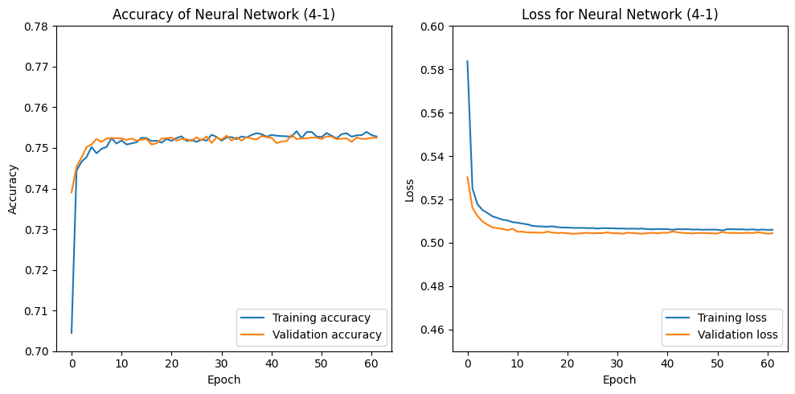

```python
import matplotlib.pyplot as plt

fig, axes = plt.subplots(1, 2, figsize=(10, 5))

axes[0].plot(history.history['accuracy'], label='Training accuracy')
axes[0].plot(history.history['val_accuracy'], label='Validation accuracy')
axes[0].set_title("Accuracy of Neural Network (4-1)")
axes[0].set_xlabel('Epoch')
axes[0].set_ylabel('Accuracy')
axes[0].set_ylim([0.7, 0.78])
axes[0].legend(loc='lower right')

axes[1].plot(history.history['loss'], label='Training loss')
axes[1].plot(history.history['val_loss'], label='Validation loss')
axes[1].set_title("Loss for Neural Network (4-1)")
axes[1].set_xlabel('Epoch')
axes[1].set_ylabel('Loss')
axes[1].set_ylim([0.45, 0.6])
axes[1].legend(loc='lower right')

plt.tight_layout()
plt.show()
```

### 6.7: The **(2-1)** architecture neural network

#### **Create the model**

```python
model_number = 7

model = Sequential()

model.add(Dense(2, activation='sigmoid', input_shape=(X.shape[1],)))
model.add(Dense(1, activation='sigmoid'))
```

```python
model.summary()

# Used to create tabular data.
parameter_counts[model_number]  = model.count_params()
```

```
Model: "sequential_10"
```

```
┏━━━━━━━━━━━━━━━━━━━━━━━━━━━━━━━━━━━━━━┳━━━━━━━━━━━━━━━━━━━━━━━━━━━━━┳━━━━━━━━━━━━━━━━━┓
┃ Layer (type)                         ┃ Output Shape                ┃         Param # ┃
┡━━━━━━━━━━━━━━━━━━━━━━━━━━━━━━━━━━━━━━╇━━━━━━━━━━━━━━━━━━━━━━━━━━━━━╇━━━━━━━━━━━━━━━━━┩
│ dense_30 (Dense)                     │ (None, 2)                   │              44 │
├──────────────────────────────────────┼─────────────────────────────┼─────────────────┤
│ dense_31 (Dense)                     │ (None, 1)                   │               3 │
└──────────────────────────────────────┴─────────────────────────────┴─────────────────┘
```

```
 Total params: 47 (188.00 B)
```

```
 Trainable params: 47 (188.00 B)
```

```
 Non-trainable params: 0 (0.00 B)
```

#### **Compile and run the model**

```python
model.compile(loss='binary_crossentropy', optimizer = 'rmsprop', metrics=['accuracy','recall'])
callback_a = ModelCheckpoint(filepath = 'my_best_model.weights.h5', monitor='val_loss', save_best_only = True, save_weights_only = True, verbose = 1)
callback_b = EarlyStopping(monitor='val_loss', mode='min', patience=40, verbose=1)


history = model.fit(X_training, Y_training, validation_data=(X_validation, Y_validation), epochs=200,
                           batch_size=16, callbacks = [callback_a, callback_b])
```

```
1323/1326 ━━━━━━━━━━━━━━━━━━━━ 0s 2ms/step - accuracy: 0.5870 - loss: 0.7011 - recall: 0.9475
Epoch 1: val_loss improved from inf to 0.56657, saving model to my_best_model.weights.h5
1326/1326 ━━━━━━━━━━━━━━━━━━━━ 8s 6ms/step - accuracy: 0.5873 - loss: 0.7009 - recall: 0.9473 - val_accuracy: 0.7434 - val_loss: 0.5666 - val_recall: 0.7962
1305/1326 ━━━━━━━━━━━━━━━━━━━━ 0s 2ms/step - accuracy: 0.7427 - loss: 0.5576 - recall: 0.7827
Epoch 2: val_loss improved from 0.56657 to 0.53970, saving model to my_best_model.weights.h5
1326/1326 ━━━━━━━━━━━━━━━━━━━━ 8s 4ms/step - accuracy: 0.7427 - loss: 0.5575 - recall: 0.7825 - val_accuracy: 0.7478 - val_loss: 0.5397 - val_recall: 0.7740
1315/1326 ━━━━━━━━━━━━━━━━━━━━ 0s 2ms/step - accuracy: 0.7412 - loss: 0.5418 - recall: 0.7607
Epoch 3: val_loss improved from 0.53970 to 0.52903, saving model to my_best_model.weights.h5
1326/1326 ━━━━━━━━━━━━━━━━━━━━ 10s 4ms/step - accuracy: 0.7412 - loss: 0.5417 - recall: 0.7607 - val_accuracy: 0.7492 - val_loss: 0.5290 - val_recall: 0.7695
1307/1326 ━━━━━━━━━━━━━━━━━━━━ 0s 2ms/step - accuracy: 0.7449 - loss: 0.5333 - recall: 0.7674
Epoch 4: val_loss improved from 0.52903 to 0.52391, saving model to my_best_model.weights.h5
1326/1326 ━━━━━━━━━━━━━━━━━━━━ 8s 6ms/step - accuracy: 0.7449 - loss: 0.5333 - recall: 0.7674 - val_accuracy: 0.7494 - val_loss: 0.5239 - val_recall: 0.7715
1322/1326 ━━━━━━━━━━━━━━━━━━━━ 0s 2ms/step - accuracy: 0.7468 - loss: 0.5241 - recall: 0.7666
Epoch 5: val_loss improved from 0.52391 to 0.52094, saving model to my_best_model.weights.h5
1326/1326 ━━━━━━━━━━━━━━━━━━━━ 8s 4ms/step - accuracy: 0.7468 - loss: 0.5241 - recall: 0.7666 - val_accuracy: 0.7497 - val_loss: 0.5209 - val_recall: 0.7679
1320/1326 ━━━━━━━━━━━━━━━━━━━━ 0s 2ms/step - accuracy: 0.7471 - loss: 0.5255 - recall: 0.7736
Epoch 6: val_loss improved from 0.52094 to 0.51874, saving model to my_best_model.weights.h5
1326/1326 ━━━━━━━━━━━━━━━━━━━━ 8s 6ms/step - accuracy: 0.7471 - loss: 0.5255 - recall: 0.7736 - val_accuracy: 0.7503 - val_loss: 0.5187 - val_recall: 0.7814
1296/1326 ━━━━━━━━━━━━━━━━━━━━ 0s 2ms/step - accuracy: 0.7465 - loss: 0.5206 - recall: 0.7783
Epoch 7: val_loss improved from 0.51874 to 0.51731, saving model to my_best_model.weights.h5
1326/1326 ━━━━━━━━━━━━━━━━━━━━ 5s 4ms/step - accuracy: 0.7465 - loss: 0.5206 - recall: 0.7783 - val_accuracy: 0.7502 - val_loss: 0.5173 - val_recall: 0.7754
1311/1326 ━━━━━━━━━━━━━━━━━━━━ 0s 2ms/step - accuracy: 0.7427 - loss: 0.5250 - recall: 0.7725
Epoch 8: val_loss improved from 0.51731 to 0.51610, saving model to my_best_model.weights.h5
1326/1326 ━━━━━━━━━━━━━━━━━━━━ 7s 5ms/step - accuracy: 0.7428 - loss: 0.5250 - recall: 0.7726 - val_accuracy: 0.7513 - val_loss: 0.5161 - val_recall: 0.7910
1326/1326 ━━━━━━━━━━━━━━━━━━━━ 0s 2ms/step - accuracy: 0.7443 - loss: 0.5215 - recall: 0.7769
Epoch 9: val_loss improved from 0.51610 to 0.51503, saving model to my_best_model.weights.h5
1326/1326 ━━━━━━━━━━━━━━━━━━━━ 7s 6ms/step - accuracy: 0.7443 - loss: 0.5215 - recall: 0.7769 - val_accuracy: 0.7512 - val_loss: 0.5150 - val_recall: 0.7899
1322/1326 ━━━━━━━━━━━━━━━━━━━━ 0s 2ms/step - accuracy: 0.7502 - loss: 0.5171 - recall: 0.7852
Epoch 10: val_loss improved from 0.51503 to 0.51427, saving model to my_best_model.weights.h5
1326/1326 ━━━━━━━━━━━━━━━━━━━━ 11s 6ms/step - accuracy: 0.7502 - loss: 0.5171 - recall: 0.7852 - val_accuracy: 0.7509 - val_loss: 0.5143 - val_recall: 0.7858
1314/1326 ━━━━━━━━━━━━━━━━━━━━ 0s 2ms/step - accuracy: 0.7470 - loss: 0.5211 - recall: 0.7855
Epoch 11: val_loss improved from 0.51427 to 0.51352, saving model to my_best_model.weights.h5
1326/1326 ━━━━━━━━━━━━━━━━━━━━ 7s 5ms/step - accuracy: 0.7470 - loss: 0.5211 - recall: 0.7855 - val_accuracy: 0.7513 - val_loss: 0.5135 - val_recall: 0.7878
1321/1326 ━━━━━━━━━━━━━━━━━━━━ 0s 2ms/step - accuracy: 0.7432 - loss: 0.5213 - recall: 0.7869
Epoch 12: val_loss improved from 0.51352 to 0.51286, saving model to my_best_model.weights.h5
1326/1326 ━━━━━━━━━━━━━━━━━━━━ 6s 5ms/step - accuracy: 0.7433 - loss: 0.5213 - recall: 0.7869 - val_accuracy: 0.7510 - val_loss: 0.5129 - val_recall: 0.7890
1299/1326 ━━━━━━━━━━━━━━━━━━━━ 0s 2ms/step - accuracy: 0.7443 - loss: 0.5202 - recall: 0.7871
Epoch 13: val_loss improved from 0.51286 to 0.51235, saving model to my_best_model.weights.h5
1326/1326 ━━━━━━━━━━━━━━━━━━━━ 7s 6ms/step - accuracy: 0.7443 - loss: 0.5202 - recall: 0.7872 - val_accuracy: 0.7512 - val_loss: 0.5124 - val_recall: 0.7873
1308/1326 ━━━━━━━━━━━━━━━━━━━━ 0s 2ms/step - accuracy: 0.7544 - loss: 0.5137 - recall: 0.7942
```

[output cut: 519 more lines]

```
Epoch 187: val_loss did not improve from 0.50467
1326/1326 ━━━━━━━━━━━━━━━━━━━━ 9s 7ms/step - accuracy: 0.7498 - loss: 0.5088 - recall: 0.8058 - val_accuracy: 0.7535 - val_loss: 0.5047 - val_recall: 0.8053
1311/1326 ━━━━━━━━━━━━━━━━━━━━ 0s 2ms/step - accuracy: 0.7490 - loss: 0.5105 - recall: 0.8012
Epoch 188: val_loss did not improve from 0.50467
1326/1326 ━━━━━━━━━━━━━━━━━━━━ 8s 6ms/step - accuracy: 0.7490 - loss: 0.5105 - recall: 0.8012 - val_accuracy: 0.7530 - val_loss: 0.5050 - val_recall: 0.7909
1318/1326 ━━━━━━━━━━━━━━━━━━━━ 0s 2ms/step - accuracy: 0.7431 - loss: 0.5114 - recall: 0.7983
Epoch 189: val_loss did not improve from 0.50467
1326/1326 ━━━━━━━━━━━━━━━━━━━━ 8s 4ms/step - accuracy: 0.7431 - loss: 0.5114 - recall: 0.7983 - val_accuracy: 0.7537 - val_loss: 0.5047 - val_recall: 0.8100
1309/1326 ━━━━━━━━━━━━━━━━━━━━ 0s 2ms/step - accuracy: 0.7463 - loss: 0.5115 - recall: 0.8039
Epoch 190: val_loss did not improve from 0.50467
1326/1326 ━━━━━━━━━━━━━━━━━━━━ 8s 6ms/step - accuracy: 0.7463 - loss: 0.5115 - recall: 0.8039 - val_accuracy: 0.7526 - val_loss: 0.5049 - val_recall: 0.8124
1296/1326 ━━━━━━━━━━━━━━━━━━━━ 0s 2ms/step - accuracy: 0.7482 - loss: 0.5130 - recall: 0.8034
Epoch 191: val_loss did not improve from 0.50467
1326/1326 ━━━━━━━━━━━━━━━━━━━━ 10s 6ms/step - accuracy: 0.7483 - loss: 0.5129 - recall: 0.8034 - val_accuracy: 0.7533 - val_loss: 0.5048 - val_recall: 0.8044
Epoch 191: early stopping
```

#### **Evaluate the model**

```python
train_scores = model.evaluate(X_training, Y_training)
val_scores = model.evaluate(X_validation, Y_validation)
```

```
663/663 ━━━━━━━━━━━━━━━━━━━━ 1s 2ms/step - accuracy: 0.7539 - loss: 0.5061 - recall: 0.8061
1547/1547 ━━━━━━━━━━━━━━━━━━━━ 2s 1ms/step - accuracy: 0.7489 - loss: 0.5086 - recall: 0.7974
```

```python
prediction_train= model.predict(X_training)
prediction_val = model.predict(X_validation)
```

```
663/663 ━━━━━━━━━━━━━━━━━━━━ 1s 1ms/step
1547/1547 ━━━━━━━━━━━━━━━━━━━━ 2s 1ms/step
```

```python
# For training and validation accuracy.
training_accuracies[model_number] = (accuracy_score(Y_training, prediction_train.round())) * 100
validation_accuracies[model_number] = (accuracy_score(Y_validation, prediction_val.round())) * 100
train_acc = training_accuracies[model_number]
val_acc = validation_accuracies[model_number]

# For training and validation loss.
training_losses[model_number] = train_scores[0]
validation_losses[model_number] = val_scores[0]
train_loss = training_losses[model_number]
val_loss = validation_losses[model_number]

# For training and validation recall.
training_recalls[model_number] = recall_score(Y_training, prediction_train.round())
validation_recalls[model_number] = recall_score(Y_validation, prediction_val.round())
train_recall = training_recalls[model_number]
val_recall = validation_recalls[model_number]

# For training and validation F1-score.
training_f1_scores[model_number] = f1_score(Y_training, prediction_train.round())
validation_f1_scores[model_number] = f1_score(Y_validation, prediction_val.round())
train_f1_score = training_f1_scores[model_number]
val_f1_score = validation_f1_scores[model_number]

# For training and validation AUC-ROC score.
training_roc_auc_scores[model_number] = roc_auc_score(Y_training, prediction_train.round())
validation_roc_auc_scores[model_number] = roc_auc_score(Y_validation, prediction_val.round())
train_roc_auc = training_roc_auc_scores[model_number]
val_roc_auc = validation_roc_auc_scores[model_number]

# For epoch count.
epoch_counts[model_number] = len(history.history['loss'])
epochs = epoch_counts[model_number]

print("\t\tTraining\tValidation")
print(f"Accuracy: \t{train_acc.item():.2f}% \t\t{val_acc.item():.2f}%")
print(f"Loss: \t\t{train_loss.item():.4f}\t\t{val_loss.item():.4f}")
print(f"Recall: \t{train_recall.item():.4f} \t\t{val_recall.item():.4f}")
print(f"F1-score: \t{train_f1_score.item():.4f} \t\t{val_f1_score.item():.4f}")
print(f"AUC-ROC score: \t{train_roc_auc.item():.4f} \t\t{train_roc_auc.item():.4f}")

print("\nPredictions:", prediction_val[0:10].T.round())
print("Number of epochs ran:\t", epochs.item())
```

```
		Training	Validation
Accuracy: 	74.89% 		75.33%
Loss: 		0.5097		0.5048
Recall: 	0.8002 		0.8044
F1-score: 	0.7617 		0.7651
AUC-ROC score: 	0.7488 		0.7488

Predictions: [[0. 0. 1. 1. 0. 0. 1. 0. 1. 0.]]
Number of epochs ran:	 191
```

#### **Visualize the model's results**

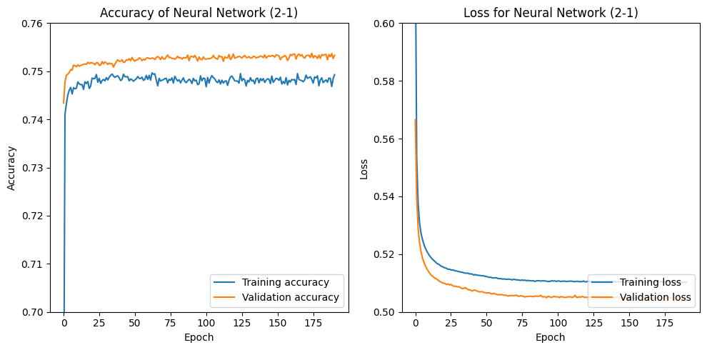

```python
import matplotlib.pyplot as plt

fig, axes = plt.subplots(1, 2, figsize=(10, 5))

axes[0].plot(history.history['accuracy'], label='Training accuracy')
axes[0].plot(history.history['val_accuracy'], label='Validation accuracy')
axes[0].set_title("Accuracy of Neural Network (2-1)")
axes[0].set_xlabel('Epoch')
axes[0].set_ylabel('Accuracy')
axes[0].set_ylim([0.7, 0.76])
axes[0].legend(loc='lower right')

axes[1].plot(history.history['loss'], label='Training loss')
axes[1].plot(history.history['val_loss'], label='Validation loss')
axes[1].set_title("Loss for Neural Network (2-1)")
axes[1].set_xlabel('Epoch')
axes[1].set_ylabel('Loss')
axes[1].set_ylim([0.5, 0.6])
axes[1].legend(loc='lower right')

plt.tight_layout()
plt.show()
```